# IODS-final

Heidi Maanonen

heidi.maanonen@helsinki.fi

26.2.2017

# 1 The purpose of the final work

The idea of the this final work is to show and demonstrate what I have learnt about R, data visualizing and statistics during this course called **Introduction to Open Data Science**. The course is organized by [University of Helsinki](https://wiki.helsinki.fi/display/SocStats/Introduction+to+Open+Data+Science,+spring+2017). I really want highlight that this was and is my first course and work with R programming. Considering this I like to believe that I have learnt a lot of very interesting ways of using R, RStudio and Rpackages.

In this final work we have 2 options to choose our data. First we could use one of the the datasets which we had already applied. Alternatively we could try to find a new dataset from internet in terms of our interests or just to raise the degree of difficulty, I think. And because I’m very interested in research, I wanted to find a new dataset to learn how to do the whole data wrangling and exploring process by myself.

My intention here is to deepen my knowledge on [Principal Component Analysis](https://en.wikipedia.org/wiki/Principal_component_analysis) in terms of finding some latent structure of the dataset introduced in the next chapter.

# 2 Description of the dataset

I choose the dataset from [Kaggle](https://www.kaggle.com/miroslavsabo/young-people-survey), which is about **Preferencies, interests, habits, opinions and fears of young people** in Slovakia. In 2013, students of the Statistics class at [FSEV UK](https://fses.uniba.sk/en/) were asked to invite their friends to participate in this survey. Accordingly they managed to get 1 010 participants for this purpose.

If you take a look at the Kaggle link you can see that there are huge amount of variables, that is 150 columns mainly integers but also some categorical variables. Thus for the purpose of this assignment and Principal Component Analysis I had to choose some interesting content which is funny because I choose the interests and hobbies of these young people. In addition, I also wanted to count in some demographical variables to make visualizations more versatile.

## 2.1 Data wrangling

You can find all of the datasets from my [GitHub Repository](https://github.com/8475394/IODS-final/tree/master/Data). The CSV-file called “raw_young_people_survey” is the original dataset from Kaggle. The “create_interests.R” is the R Script file of my data wrangling and the “interests_dem.txt” is the file what I’m going to use here.

BRIEF DESCRIPTION OF DATA WRANGLING PHASES:

1. Reading the whole dataset
2. Selecting the variables of interests and hobbies including age and gender
3. Renaming some variables
4. Exploring missing values
5. Removing the rows with missing values
6. Saving the new data

SECOND PART OF DATA WRANGLING:

While printing the summaries and plotting histograms I noticed that there is something “wrong” with the gender variable. This column consisted the third unnamed category containing only three participant. I assumed that these people didn’t want answer to this question. But the point from data wrangling perspective was that this third category was unnamed while these were not marked as missing values. Still the Kaggle pages informed that the gender is divided to females and males. Thus, I couldn’t actually know the real purpose so I made a decision to extract these particpant from the data. You can find this part from the same R Script named as “create_interests.R”. Below you can see a short description of the second part.

7. Recoding empty values as NA:s
8. Verifying that 3 of the values belong to NA:s
9. Removing the “new” rows with missing values
10. Saving the dataset again as “interests_dem.txt”

## 2.2 Introducing the variables

From the structure table below you see that after data wrangling part there are 878 observation and 34 variables, mostly integers, treated as continuous variables, and 1 factor variable. The first 32 variables represent different interests and hobbies of young people which were measured on the [Likert Scale](https://en.wikipedia.org/wiki/Likert_scale) from 1 to 5 (Not interested - Very interested). Last two variables contains information about age and gender, where the former varies between 15 and 30 years. The latter contains categories of female and male.

Some of these variables may need some additional information, thus I made a table for their longer and short names. However, most of the variables have same longer and shorter name. See the table after exploring the structure of the data.

DATA STRUCTURE

```r
# Reading the data with interests and demographics
interests_dem <- read.table(file.path("C:/Users/heidi/Documents/YLIOPISTO/TILASTOTIEDE/INTRODUCTION TO OPEN DATA SCIENCE/IODS-final/data", "interests_dem.txt"), header = TRUE)

# Printing the data structure
library(dplyr)
glimpse(interests_dem)
```

```
## Observations: 878
## Variables: 34
## $ History      <int> 1, 1, 1, 4, 3, 5, 3, 5, 3, 3, 3, 2, 4, 2, 2, 5, 1...
## $ Psychology   <int> 5, 3, 2, 4, 2, 3, 3, 2, 2, 2, 3, 2, 4, 2, 5, 5, 1...
## $ Politics     <int> 1, 4, 1, 5, 3, 4, 1, 3, 1, 3, 3, 5, 4, 1, 1, 3, 1...
## $ Mathematics  <int> 3, 5, 5, 4, 2, 2, 1, 1, 1, 3, 2, 1, 1, 1, 1, 3, 1...
## $ Physics      <int> 3, 2, 2, 1, 2, 3, 1, 1, 1, 1, 1, 1, 1, 1, 1, 3, 1...
## $ Internet     <int> 5, 4, 4, 3, 2, 4, 2, 5, 1, 5, 4, 5, 3, 3, 4, 4, 5...
## $ PC           <int> 3, 4, 2, 1, 2, 4, 1, 4, 1, 1, 5, 4, 2, 3, 2, 5, 2...
## $ Economy      <int> 5, 5, 4, 2, 2, 1, 3, 1, 1, 4, 3, 1, 1, 3, 3, 3, 1...
## $ Biology      <int> 3, 1, 1, 3, 3, 4, 5, 2, 3, 2, 2, 1, 5, 1, 2, 5, 4...
## $ Chemistry    <int> 3, 1, 1, 3, 3, 4, 5, 2, 1, 1, 1, 1, 5, 1, 1, 2, 1...
## $ rPoetry      <int> 3, 4, 5, 5, 5, 3, 3, 2, 5, 4, 3, 3, 5, 4, 4, 3, 1...
## $ Geography    <int> 3, 4, 2, 4, 2, 3, 3, 3, 1, 4, 3, 5, 3, 1, 1, 3, 1...
## $ Languages    <int> 5, 5, 5, 4, 3, 4, 4, 4, 1, 5, 5, 2, 5, 5, 3, 4, 3...
```

[output cut: 21 more lines]

INTERESTS AND THEIR SHORT NAMES

| INTEREST | Short name | INTEREST | Short name |
| --- | --- | --- | --- |
| 1. History | History | 18. Religion | Religion |
| 2. Psychology | Psychology | 19. Outdoor activities | Outdoor |
| 3. Politics | Politics | 20. Dancing | Dancing |
| 4. Mathematics | Mathematics | 21. Playing musical instruments | Instruments |
| 5. Physics | Physics | 22. Poetry writing | wPoetry |
| 6. Internet | Internet | 23. Sport and leisure activities | sLeisure |
| 7. PC Software, Hardware | PC | 24. Sport at competitive level | sCompetitive |
| 8. Economy, Management | Economy | 25. Gardening | Gardening |
| 9. Biology | Biology | 26. Celebrity lifestyle | Celebrities |
| 10. Chemistry | Chemistry | 27. Shopping | Shopping |
| 11. Poetry reading | rPoetry | 28. Science and technology | SciTec |
| 12. Geography | Geography | 29. Theatre | Theatre |
| 13. Foreign languages | Languages | 30. Socializing with friends | Social |
| 14. Medicine | Medicine | 31. Adrenaline sports | sAdrenaline |
| 15. Law | Law | 32. Pets | Pets |
| 16. Cars | Cars | 33. Age | Age |
| 17. Art exhibitions | Art | 34. Gender | Gender |

## 2.3 Summary tables

The dataset contains a lot of variables, also producing many summary tables.

As you can perceive, all of the variables, besides age, varies between 1 and 5. This means that the whole scale has been used considering each of the variables. Interestingly, some distributions are quite flat, suggesting average interest toward the hobbies or interests. By this I mean that the mean and median values are around 3. These include **History, Psychology, PC, Poetry reading, Geography, Sport at competitive level, Shopping, Science and technology, Theatre and Adrenaline sports**.

Then there are some variables with quite low average interest, including for example **Physics, Chemistry, Poetry writing and Gardening** and very high interest, including **Internet, Languages, Outdoor activities and Socializing with friends**.

When exploring the distributions, it is good to remember that the participants were not just the students but also their friends. This means that the participants can come from the University, working life, etc.

```r
library(knitr); library(dplyr)
kable(summary(interests_dem[,1:7]), format = "pandoc", digits = 2,  caption = 'Summary 1', align = "l")
```

Summary 1

|  | History | Psychology | Politics | Mathematics | Physics | Internet | PC |
| --- | --- | --- | --- | --- | --- | --- | --- |
|  | Min. :1.000 | Min. :1.000 | Min. :1.000 | Min. :1.000 | Min. :1.000 | Min. :1.000 | Min. :1.000 |
|  | 1st Qu.:2.000 | 1st Qu.:2.000 | 1st Qu.:1.000 | 1st Qu.:1.000 | 1st Qu.:1.000 | 1st Qu.:4.000 | 1st Qu.:2.000 |
|  | Median :3.000 | Median :3.000 | Median :2.000 | Median :2.000 | Median :2.000 | Median :4.000 | Median :3.000 |
|  | Mean :3.207 | Mean :3.112 | Mean :2.614 | Mean :2.372 | Mean :2.083 | Mean :4.174 | Mean :3.131 |
|  | 3rd Qu.:4.000 | 3rd Qu.:4.000 | 3rd Qu.:4.000 | 3rd Qu.:3.000 | 3rd Qu.:3.000 | 3rd Qu.:5.000 | 3rd Qu.:4.000 |
|  | Max. :5.000 | Max. :5.000 | Max. :5.000 | Max. :5.000 | Max. :5.000 | Max. :5.000 | Max. :5.000 |

```r
kable(summary(interests_dem[,8:14]), format = "pandoc", digits = 2,  caption = 'Summary 2', align = "l")
```

Summary 2

|  | Economy | Biology | Chemistry | rPoetry | Geography | Languages | Medicine |
| --- | --- | --- | --- | --- | --- | --- | --- |
|  | Min. :1.000 | Min. :1.000 | Min. :1.000 | Min. :1.000 | Min. :1.000 | Min. :1.000 | Min. :1.000 |
|  | 1st Qu.:1.000 | 1st Qu.:1.000 | 1st Qu.:1.000 | 1st Qu.:2.000 | 1st Qu.:2.000 | 1st Qu.:3.000 | 1st Qu.:1.000 |
|  | Median :2.000 | Median :2.000 | Median :2.000 | Median :3.000 | Median :3.000 | Median :4.000 | Median :2.000 |
|  | Mean :2.641 | Mean :2.656 | Mean :2.151 | Mean :3.159 | Mean :3.104 | Mean :3.788 | Mean :2.514 |
|  | 3rd Qu.:4.000 | 3rd Qu.:4.000 | 3rd Qu.:3.000 | 3rd Qu.:5.000 | 3rd Qu.:4.000 | 3rd Qu.:5.000 | 3rd Qu.:3.000 |
|  | Max. :5.000 | Max. :5.000 | Max. :5.000 | Max. :5.000 | Max. :5.000 | Max. :5.000 | Max. :5.000 |

```r
kable(summary(interests_dem[,15:21]), format = "pandoc", digits = 2,  caption = 'Summary 3', align = "l")
```

Summary 3

|  | Law | Cars | Art | Religion | Outdoor | Dancing | Instruments |
| --- | --- | --- | --- | --- | --- | --- | --- |
|  | Min. :1.000 | Min. :1.000 | Min. :1.0 | Min. :1.000 | Min. :1.000 | Min. :1.000 | Min. :1.000 |
|  | 1st Qu.:1.000 | 1st Qu.:1.000 | 1st Qu.:1.0 | 1st Qu.:1.000 | 1st Qu.:3.000 | 1st Qu.:1.000 | 1st Qu.:1.000 |
|  | Median :2.000 | Median :2.000 | Median :2.0 | Median :2.000 | Median :4.000 | Median :2.000 | Median :2.000 |
|  | Mean :2.248 | Mean :2.664 | Mean :2.6 | Mean :2.267 | Mean :3.674 | Mean :2.438 | Mean :2.319 |
|  | 3rd Qu.:3.000 | 3rd Qu.:4.000 | 3rd Qu.:4.0 | 3rd Qu.:3.000 | 3rd Qu.:5.000 | 3rd Qu.:3.000 | 3rd Qu.:4.000 |
|  | Max. :5.000 | Max. :5.000 | Max. :5.0 | Max. :5.000 | Max. :5.000 | Max. :5.000 | Max. :5.000 |

```r
kable(summary(interests_dem[,22:28]), format = "pandoc", digits = 2,  caption = 'Summary 4', align = "l")
```

Summary 4

|  | wPoetry | sLeisure | sCompetitive | Gardening | Celebrities | Shopping | SciTec |
| --- | --- | --- | --- | --- | --- | --- | --- |
|  | Min. :1.000 | Min. :1.000 | Min. :1.000 | Min. :1.000 | Min. :1.000 | Min. :1.000 | Min. :1.000 |
|  | 1st Qu.:1.000 | 1st Qu.:2.000 | 1st Qu.:2.000 | 1st Qu.:1.000 | 1st Qu.:1.000 | 1st Qu.:2.000 | 1st Qu.:2.000 |
|  | Median :1.000 | Median :4.000 | Median :3.000 | Median :1.000 | Median :2.000 | Median :3.000 | Median :3.000 |
|  | Mean :1.888 | Mean :3.413 | Mean :3.274 | Mean :1.896 | Mean :2.346 | Mean :3.263 | Mean :3.249 |
|  | 3rd Qu.:3.000 | 3rd Qu.:5.000 | 3rd Qu.:5.000 | 3rd Qu.:2.750 | 3rd Qu.:3.000 | 3rd Qu.:4.000 | 3rd Qu.:4.000 |
|  | Max. :5.000 | Max. :5.000 | Max. :5.000 | Max. :5.000 | Max. :5.000 | Max. :5.000 | Max. :5.000 |

```r
kable(summary(interests_dem[,29:33]), format = "pandoc", digits = 2,  caption = 'Summary 5', align = "l")
```

Summary 5

|  | Theatre | Social | sAdrenaline | Pets | Age |
| --- | --- | --- | --- | --- | --- |
|  | Min. :1.000 | Min. :2.000 | Min. :1.000 | Min. :1.000 | Min. :15.00 |
|  | 1st Qu.:2.000 | 1st Qu.:4.000 | 1st Qu.:2.000 | 1st Qu.:2.000 | 1st Qu.:19.00 |
|  | Median :3.000 | Median :5.000 | Median :3.000 | Median :4.000 | Median :20.00 |
|  | Mean :3.024 | Mean :4.556 | Mean :2.937 | Mean :3.334 | Mean :20.39 |
|  | 3rd Qu.:4.000 | 3rd Qu.:5.000 | 3rd Qu.:4.000 | 3rd Qu.:5.000 | 3rd Qu.:21.00 |
|  | Max. :5.000 | Max. :5.000 | Max. :5.000 | Max. :5.000 | Max. :30.00 |

SUMMARY OF GENDER

This last tiny table informs us that there are 520 females and 358 males.

```r
Gender <- interests_dem$Gender
table(Gender)
```

```
## Gender
## female   male
##    520    358
```

# 3 Reasearch problem and initial hypotheses

The research problem is to reduce the dimensions of the data by **young people’s interests and hobbies** and identify and express a meaningful pattern of components in terms of clarity and exploratory fashion. First I offer some general backround information of my initial proposal and after this I present the initial hypotheses or proposal together with the colored histograms.

In this section you can see the ditributions more visually. The coloring might seem confucing at first but there is actually a strategy behind this. As I mentioned earlier, my intention is to deepen my knowledge in terms of Principal Component Analysis (PCA), hence the coloring points to **initial proposal** of the latent structure inside the data. I’m highlighting the word initial because the structure is based partially on my personal intuition and partially on the “behaviour” of the distributions. Additionally, I want to form my perception of the structure from beginning to end, rather than perform the statistical methods first and then look back and write these chapters. Thus I could call this as my learnings process.

Note that the histograms are showed regarding the original variable list while the structure is organized by proposed groups or components. Note also that gender as well as the distribution of age are visualized only for the informative purposes.

## 3.1 Initial proposal of latent structure and hypotheses

FIRST DIMENSION

In the beginning I maybe wouldn’t have chosen the psychology here but I thought it’s important that these variables share somewhat similar distributions. If these variables belong to same component, the dimension could be called something like **interest toward base disciplines of cultural characteristics with respect to human beings**.

- History
- Psychology
- Geography

SECOND DIMENSION

Also this dimension contains variables with somewhat equivalent distributions and I think they share some common parts of **intellectual elements**.

- Politics
- Economy, management
- Biology
- Medicine
- Art exhibition

THIRD DIMENSION

This dimension is a bit tricky. To me, it makes sense that the math, physics and chemistry could belong to the same scope. The variable of being interest toward law is more complicated. It could belong here or to the earlier dimension of “intellectual features”. In terms of this third dimension the content of law contains a lot of details and complex attributes as well as math, physics and chemistry. Thus, if a person is interested in putting effort **to calculate details and logical problems**, this dimension can make sense (so far).

- Mathematics
- Physics
- Chemistry
- Law

Then, my intention at first was to create one more dimension for variables below until I noticed that their distribution is likely to be similar with the above variables. First I thought that religion, playing instruments, poetry writing and gardening relate to some artistic features which still could be the explanation. But according to the information of similarities in their distributions, it could be “true” that some people are interested in all of these contents. There might be a situation that **people interested in math, physics, chemistry and law would like to have some counterbalance hobbies or worldview in terms of religion**. However, it is not very easy to figure out a name representing all these variables, thus I think I need to ensure the results first.

- Religion
- Playing musical instruments
- Poetry writing
- Gardening

FOURTH DIMENSION

At this point, the fourth dimension contains the futher variables:

- Internet
- Foreign languages
- Outdoor activities
- Sport and leisure activities
- Sport at competitive level
- Socializing with friends
- Pets

There is more variablity in this dimension considering the distributions. However, I think that all these variables share the aspect of **interest toward socializing** with one way or another.

FIFTH DIMENSION

I think that this dimension contains at least PC and interest toward science and techology, since PC can be considered as technology. This can be true also in terms of cars but its ditribution doesn’t fit. Finally it seems that the Andrenaline sports doesn’t fit anyhere. Nevertheless, if it belongs here, the dimension could be called for example **interest toward speed and technology**.

- PC
- Science and technology
- Cars
- Adrenaline sports

SIXTH DIMENSION

These variables can be close with socializing aspects regarding their actual content or meaning. However their distributions seem to somewhat different and for that reason I separated the variables below as their own dimension. It seems that within this data, these interests are more important to women than men, which could be the common nominator. Hope nobody gets hurt if I call these variables as **feminine activities**.

- Poetry reading
- Shopping
- Theatre

SEVENTH DIMENSION

This last dimension may contain the following variables:

- Dancing
- Celebrity lifestyle

I think that these share the most obvious relationship regarding their content but let’s see later if the PCA agrees with me.

## 3.2 Histograms considering the latent structure

Note that the binwidth of every histogram is set to 1 on purpose in terms to show the real amount of each level between 1 and 5. Thus I wanted to show more accurate than “more beautiful” plots. This might be one of “the curses” of the Likert scale as it kind of “wrangles” between ordinal and interval scale.

However, I will treat these variables as continuous while recognizing the debate around this topic. Here is an interesting article by Karen Grace-Martin: [Can Likert Scale Data ever be Continuous](http://www.theanalysisfactor.com/can-likert-scale-data-ever-be-continuous/).

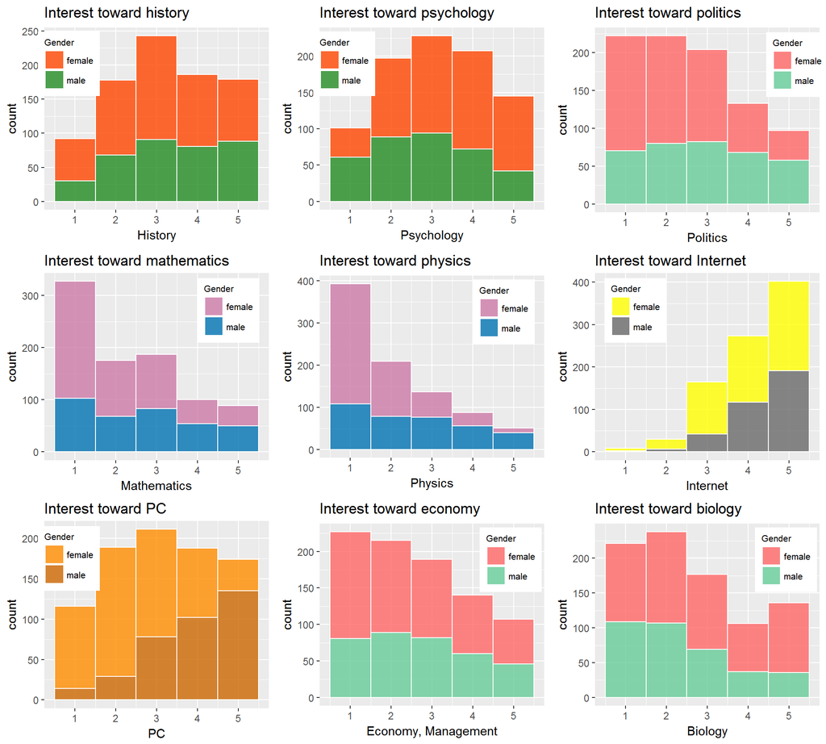

```r
library(ggplot2); library(gridExtra)

# Nice  plave to learn about ggplot: https://sesync-ci.github.io/graphics-with-ggplot2-lesson/2016/08/25/
# Palettes and colors: http://www.cookbook-r.com/Graphs/Colors_(ggplot2)/#palettes-color-brewer

h1 <- ggplot(interests_dem, aes(interests_dem$History, fill = Gender)) + geom_histogram(binwidth = 1, color = "white", alpha = 0.8) + scale_fill_manual(values=c("orangered", "forestgreen")) + theme(legend.position=c(0.11, 0.8), legend.title=element_text(size=8), legend.text = element_text(size = 8)) + ggtitle("Interest toward history") + xlab("History")

h2 <- ggplot(interests_dem, aes(interests_dem$Psychology, fill = Gender)) + geom_histogram(binwidth = 1, color = "white", alpha = 0.8) + scale_fill_manual(values=c("orangered", "forestgreen")) + theme(legend.position=c(0.11, 0.8), legend.title=element_text(size=8), legend.text = element_text(size = 8)) + ggtitle("Interest toward psychology") + xlab("Psychology")

h3 <- ggplot(interests_dem, aes(interests_dem$Politics, fill = Gender)) + geom_histogram(binwidth = 1, color = "white", alpha = 0.8) + scale_fill_manual(values=c("#FF6666", "#66CC99")) + theme(legend.position=c(0.9, 0.8), legend.title=element_text(size=8), legend.text = element_text(size = 8)) + ggtitle("Interest toward politics") + xlab("Politics")

h4 <- ggplot(interests_dem, aes(interests_dem$Mathematics, fill = Gender)) + geom_histogram(binwidth = 1, color = "white", alpha = 0.8) + scale_fill_manual(values=c("#CC79A7", "#0072B2")) + theme(legend.position=c(0.82, 0.8), legend.title=element_text(size=8), legend.text = element_text(size = 8)) + ggtitle("Interest toward mathematics") + xlab("Mathematics")

h5 <- ggplot(interests_dem, aes(interests_dem$Physics, fill = Gender)) + geom_histogram(binwidth = 1, color = "white", alpha = 0.8) + scale_fill_manual(values=c("#CC79A7", "#0072B2")) + theme(legend.position=c(0.82, 0.8), legend.title=element_text(size=8), legend.text = element_text(size = 8)) + ggtitle("Interest toward physics") + xlab("Physics")

h6 <- ggplot(interests_dem, aes(interests_dem$Internet, fill = Gender)) + geom_histogram(binwidth = 1, color = "white", alpha = 0.8) + scale_fill_manual(values=c("yellow", "dimgray")) + theme(legend.position=c(0.18, 0.8), legend.title=element_text(size=8), legend.text = element_text(size = 8)) + ggtitle("Interest toward Internet") + xlab("Internet")

h7 <- ggplot(interests_dem, aes(interests_dem$PC, fill = Gender)) + geom_histogram(binwidth = 1, color = "white", alpha = 0.8) + scale_fill_manual(values=c("darkorange", "#CC6600")) + theme(legend.position=c(0.11, 0.8), legend.title=element_text(size=8), legend.text = element_text(size = 8)) + ggtitle("Interest toward PC") + xlab("PC")

h8 <- ggplot(interests_dem, aes(interests_dem$Economy, fill = Gender)) + geom_histogram(binwidth = 1, color = "white", alpha = 0.8) + scale_fill_manual(values=c("#FF6666", "#66CC99")) + theme(legend.position=c(0.85, 0.8), legend.title=element_text(size=8), legend.text = element_text(size = 8)) + ggtitle("Interest toward economy") + xlab("Economy, Management")

h9 <- ggplot(interests_dem, aes(interests_dem$Biology, fill = Gender)) + geom_histogram(binwidth = 1, color = "white", alpha = 0.8) + scale_fill_manual(values=c("#FF6666", "#66CC99")) + theme(legend.position=c(0.85, 0.8), legend.title=element_text(size=8), legend.text = element_text(size = 8)) + ggtitle("Interest toward biology") + xlab("Biology")

grid.arrange(h1, h2, h3, h4, h5, h6, h7, h8, h9, ncol = 3, nrow =3)
```

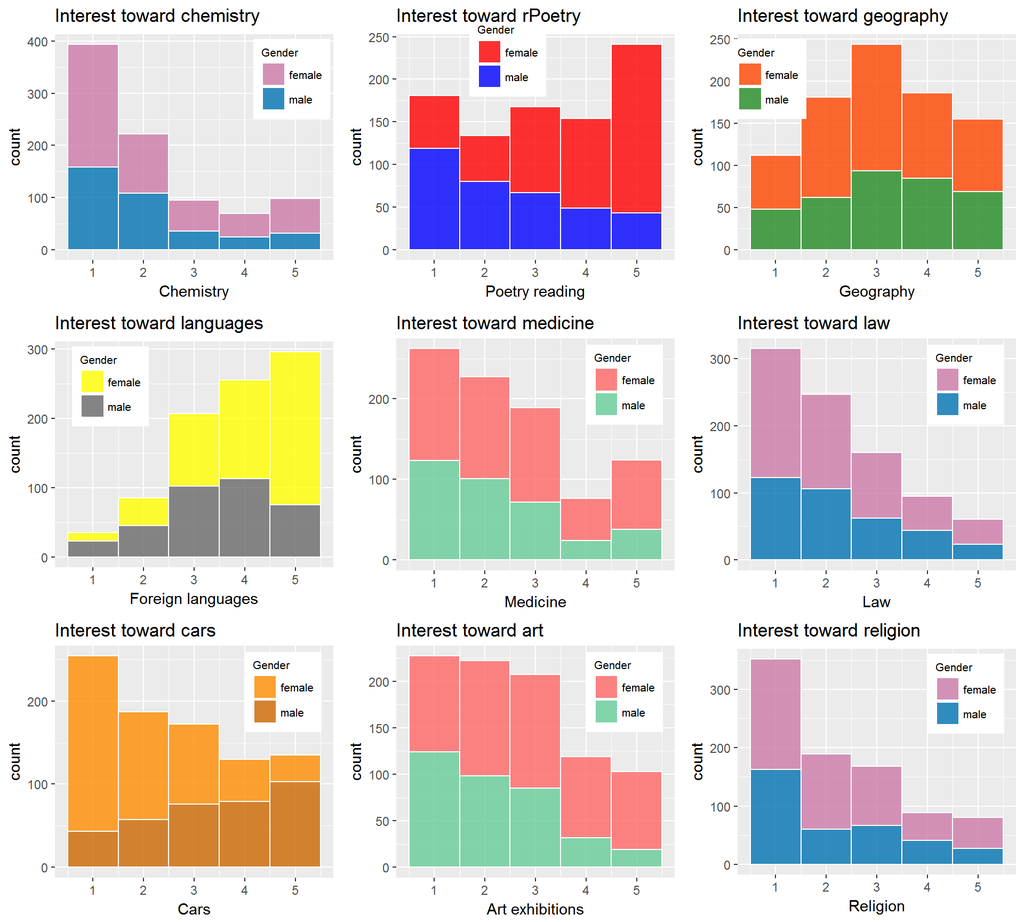

```r
library(ggplot2); library(gridExtra)

h10 <- ggplot(interests_dem, aes(interests_dem$Chemistry, fill = Gender)) + geom_histogram(binwidth = 1, color = "white", alpha = 0.8) + scale_fill_manual(values=c("#CC79A7", "#0072B2")) + theme(legend.position=c(0.85, 0.8), legend.title=element_text(size=8), legend.text = element_text(size = 8)) + ggtitle("Interest toward chemistry") + xlab("Chemistry")

h11 <- ggplot(interests_dem, aes(interests_dem$rPoetry, fill = Gender)) + geom_histogram(binwidth = 1, color = "white", alpha = 0.8) + scale_fill_manual(values=c("#FF0000", "blue")) + theme(legend.position=c(0.4, 0.9), legend.title=element_text(size=8), legend.text = element_text(size = 8)) + ggtitle("Interest toward rPoetry") + xlab("Poetry reading")

h12 <- ggplot(interests_dem, aes(interests_dem$Geography, fill = Gender)) + geom_histogram(binwidth = 1, color = "white", alpha = 0.8) + scale_fill_manual(values=c("orangered", "forestgreen")) + theme(legend.position=c(0.11, 0.8), legend.title=element_text(size=8), legend.text = element_text(size = 8)) + ggtitle("Interest toward geography") + xlab("Geography")

h13 <- ggplot(interests_dem, aes(interests_dem$Languages, fill = Gender)) + geom_histogram(binwidth = 1, color = "white", alpha = 0.8) + scale_fill_manual(values=c("yellow", "dimgray")) + theme(legend.position=c(0.2, 0.8), legend.title=element_text(size=8), legend.text = element_text(size = 8)) + ggtitle("Interest toward languages") + xlab("Foreign languages")

h14 <- ggplot(interests_dem, aes(interests_dem$Medicine, fill = Gender)) + geom_histogram(binwidth = 1, color = "white", alpha = 0.8) + scale_fill_manual(values=c("#FF6666", "#66CC99")) + theme(legend.position=c(0.82, 0.8), legend.title=element_text(size=8), legend.text = element_text(size = 8)) + ggtitle("Interest toward medicine") + xlab("Medicine")

h15 <- ggplot(interests_dem, aes(interests_dem$Law, fill = Gender)) + geom_histogram(binwidth = 1, color = "white", alpha = 0.8) + scale_fill_manual(values=c("#CC79A7", "#0072B2")) + theme(legend.position=c(0.82, 0.8), legend.title=element_text(size=8), legend.text = element_text(size = 8)) + ggtitle("Interest toward law") + xlab("Law")

h16 <- ggplot(interests_dem, aes(interests_dem$Cars, fill = Gender)) + geom_histogram(binwidth = 1, color = "white", alpha = 0.8) + scale_fill_manual(values=c("darkorange", "#CC6600")) + theme(legend.position=c(0.82, 0.8), legend.title=element_text(size=8), legend.text = element_text(size = 8)) + ggtitle("Interest toward cars") + xlab("Cars")

h17 <- ggplot(interests_dem, aes(interests_dem$Art, fill = Gender)) + geom_histogram(binwidth = 1, color = "white", alpha = 0.8) + scale_fill_manual(values=c("#FF6666", "#66CC99")) + theme(legend.position=c(0.82, 0.8), legend.title=element_text(size=8), legend.text = element_text(size = 8)) + ggtitle("Interest toward art") + xlab("Art exhibitions")

h18 <- ggplot(interests_dem, aes(interests_dem$Religion, fill = Gender)) + geom_histogram(binwidth = 1, color = "white", alpha = 0.8) + scale_fill_manual(values=c("#CC79A7", "#0072B2")) + theme(legend.position=c(0.82, 0.8), legend.title=element_text(size=8), legend.text = element_text(size = 8)) + ggtitle("Interest toward religion") + xlab("Religion")

grid.arrange(h10, h11, h12, h13, h14, h15, h16, h17, h18, ncol = 3, nrow =3)
```

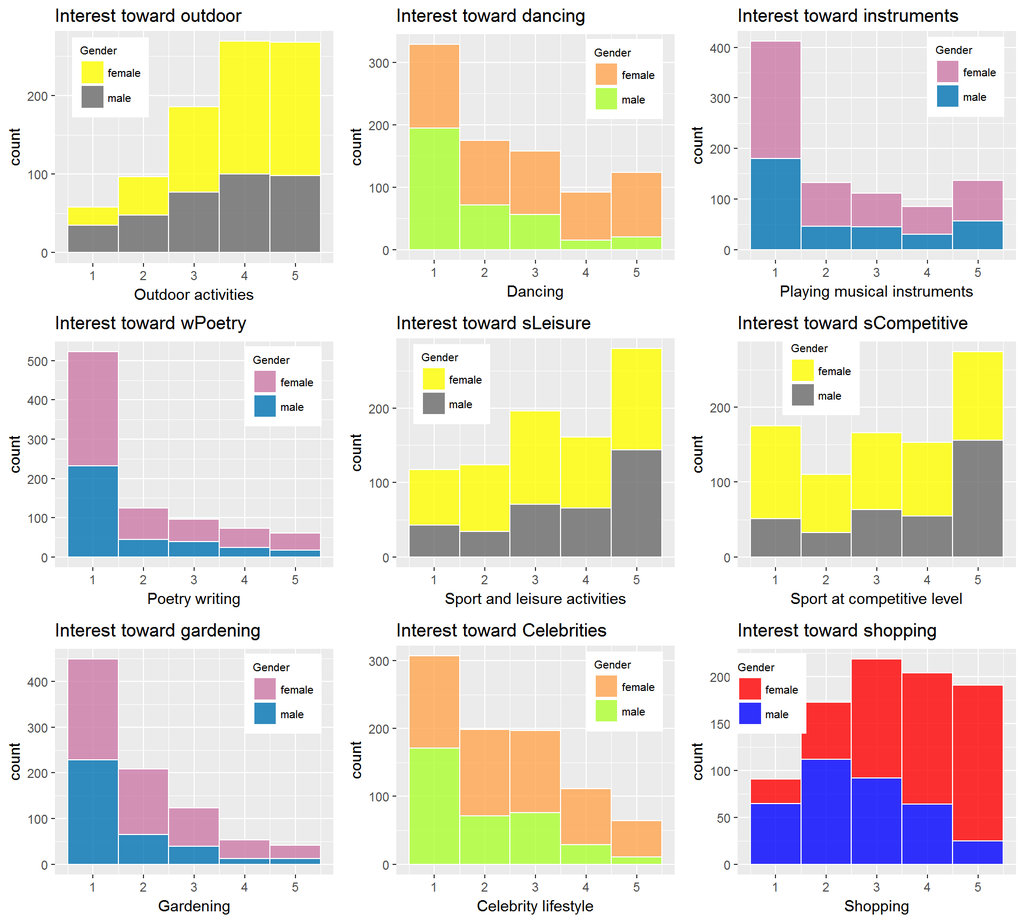

```r
library(ggplot2); library(gridExtra)

h19 <- ggplot(interests_dem, aes(interests_dem$Outdoor, fill = Gender)) + geom_histogram(binwidth = 1, color = "white", alpha = 0.8) + scale_fill_manual(values=c("yellow", "dimgray")) + theme(legend.position=c(0.2, 0.8), legend.title=element_text(size=8), legend.text = element_text(size = 8)) + ggtitle("Interest toward outdoor") + xlab("Outdoor activities")

h20 <- ggplot(interests_dem, aes(interests_dem$Dancing, fill = Gender)) + geom_histogram(binwidth = 1, color = "white", alpha = 0.8) + scale_fill_manual(values=c("tan1", "greenyellow")) + theme(legend.position=c(0.82, 0.8), legend.title=element_text(size=8), legend.text = element_text(size = 8)) + ggtitle("Interest toward dancing") + xlab("Dancing")

h21 <- ggplot(interests_dem, aes(interests_dem$Instruments, fill = Gender)) + geom_histogram(binwidth = 1, color = "white", alpha = 0.8) + scale_fill_manual(values=c("#CC79A7", "#0072B2")) + theme(legend.position=c(0.82, 0.8), legend.title=element_text(size=8), legend.text = element_text(size = 8)) + ggtitle("Interest toward instruments") + xlab("Playing musical instruments")

h22 <- ggplot(interests_dem, aes(interests_dem$wPoetry, fill = Gender)) + geom_histogram(binwidth = 1, color = "white", alpha = 0.8) + scale_fill_manual(values=c("#CC79A7", "#0072B2")) + theme(legend.position=c(0.82, 0.8), legend.title=element_text(size=8), legend.text = element_text(size = 8)) + ggtitle("Interest toward wPoetry") + xlab("Poetry writing")

h23 <- ggplot(interests_dem, aes(interests_dem$sLeisure, fill = Gender)) + geom_histogram(binwidth = 1, color = "white", alpha = 0.8) + scale_fill_manual(values=c("yellow", "dimgray")) + theme(legend.position=c(0.2, 0.8), legend.title=element_text(size=8), legend.text = element_text(size = 8)) + ggtitle("Interest toward sLeisure") + xlab("Sport and leisure activities")

h24 <- ggplot(interests_dem, aes(interests_dem$sCompetitive, fill = Gender)) + geom_histogram(binwidth = 1, color = "white", alpha = 0.8) + scale_fill_manual(values=c("yellow", "dimgray")) + theme(legend.position=c(0.3, 0.85), legend.title=element_text(size=8), legend.text = element_text(size = 8)) + ggtitle("Interest toward sCompetitive") + xlab("Sport at competitive level")

h25 <- ggplot(interests_dem, aes(interests_dem$Gardening, fill = Gender)) + geom_histogram(binwidth = 1, color = "white", alpha = 0.8) + scale_fill_manual(values=c("#CC79A7", "#0072B2")) + theme(legend.position=c(0.82, 0.8), legend.title=element_text(size=8), legend.text = element_text(size = 8)) + ggtitle("Interest toward gardening") + xlab("Gardening")

h26 <- ggplot(interests_dem, aes(interests_dem$Celebrities, fill = Gender)) + geom_histogram(binwidth = 1, color = "white", alpha = 0.8) + scale_fill_manual(values=c("tan1", "greenyellow")) + theme(legend.position=c(0.82, 0.8), legend.title=element_text(size=8), legend.text = element_text(size = 8)) + ggtitle("Interest toward Celebrities") + xlab("Celebrity lifestyle")

h27 <- ggplot(interests_dem, aes(interests_dem$Shopping, fill = Gender)) + geom_histogram(binwidth = 1, color = "white", alpha = 0.8) + scale_fill_manual(values=c("#FF0000", "blue")) + theme(legend.position=c(0.11, 0.8), legend.title=element_text(size=8), legend.text = element_text(size = 8)) + ggtitle("Interest toward shopping") + xlab("Shopping")

grid.arrange(h19, h20, h21, h22, h23, h24, h25, h26, h27, ncol = 3, nrow =3)
```

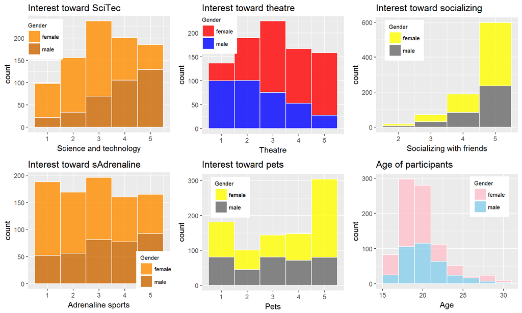

```r
library(ggplot2); library(gridExtra)


h28 <- ggplot(interests_dem, aes(interests_dem$SciTec, fill = Gender)) + geom_histogram(binwidth = 1, color = "white", alpha = 0.8) + scale_fill_manual(values=c("darkorange", "#CC6600")) + theme(legend.position=c(0.11, 0.8), legend.title=element_text(size=8), legend.text = element_text(size = 8)) + ggtitle("Interest toward SciTec") + xlab("Science and technology")

h29 <- ggplot(interests_dem, aes(interests_dem$Theatre, fill = Gender)) + geom_histogram(binwidth = 1, color = "white", alpha = 0.8) + scale_fill_manual(values=c("#FF0000", "blue")) + theme(legend.position=c(0.11, 0.85), legend.title=element_text(size=8), legend.text = element_text(size = 8)) + ggtitle("Interest toward theatre") + xlab("Theatre")

h30 <- ggplot(interests_dem, aes(interests_dem$Social, fill = Gender)) + geom_histogram(binwidth = 1, color = "white", alpha = 0.8) + scale_fill_manual(values=c("yellow", "dimgray")) + theme(legend.position=c(0.2, 0.8), legend.title=element_text(size=8), legend.text = element_text(size = 8)) + ggtitle("Interest toward socializing") + xlab("Socializing with friends")

h31 <- ggplot(interests_dem, aes(interests_dem$sAdrenaline, fill = Gender)) + geom_histogram(binwidth = 1, color = "white", alpha = 0.8) + scale_fill_manual(values=c("darkorange", "#CC6600")) + theme(legend.position=c(0.9, 0.15), legend.title=element_text(size=8), legend.text = element_text(size = 8)) + ggtitle("Interest toward sAdrenaline") + xlab("Adrenaline sports")

h32 <- ggplot(interests_dem, aes(interests_dem$Pets, fill = Gender)) + geom_histogram(binwidth = 1, color = "white", alpha = 0.8) + scale_fill_manual(values=c("yellow", "dimgray")) + theme(legend.position=c(0.2, 0.8), legend.title=element_text(size=8), legend.text = element_text(size = 8)) + ggtitle("Interest toward pets") + xlab("Pets")

h33 <- ggplot(interests_dem, aes(interests_dem$Age, fill = Gender)) + geom_histogram(binwidth = 2, color = "white", alpha = 0.8) + scale_fill_manual(values=c("pink", "skyblue")) + theme(legend.position=c(0.8, 0.8), legend.title=element_text(size=8), legend.text = element_text(size = 8)) + ggtitle("Age of participants") + xlab("Age")

grid.arrange(h28, h29, h30, h31, h32, h33, ncol = 3, nrow =2)
```

# 4 Relationships between different interests

Here my intention is to explore the potential relationships between the different interests and hobbies. First I had to **extract the age and the gender** since they were not a part of my dimension reduction analysis. Then, I had this notable problem with the amount of my variables. First, I printed the correlation matrix including all 32 variable but the table grew so large that it was very difficult to explore it. Also, I figured that the matrix and correlation plot didn’t fit well to the web page. Thus, I divided the dataset into the 3 subset to present the correlations at least in some extent.

**The subsets are divided in a following order**: The first set considers the first 10 variables and the second contains the subsequent 10 variables, i.e. from 11th to 20th. The last subset consists the last 12 variables from 21th to 32th.

Within the next sub chapters I present the **correlation matrixes**, the tables of their **p-values**, i.e. significance tests and finally I demonstrate both correlations and their significance in **one plot per subset**. I adopted the significance test and its further use with the corrplot from [sthda.com’s web examples](http://www.sthda.com/english/wiki/visualize-correlation-matrix-using-correlogram).

## 4.1 First set of correlations

```r
library(dplyr); library(knitr); library(corrplot)
interests <- dplyr::select(interests_dem, 1:32) # leaving age and gender out

# Dividing the data to groups
interests1 <- dplyr::select(interests, 1:10) # Selecting first set of variables
interests2 <- dplyr::select(interests, 11:20) # Selecting second set of variables
interests3 <- dplyr::select(interests, 21:32) # Selecting rest of the variables

# Presenting the first correlation matrix
cor_matrix1 <- cor(interests1) %>% round(digits = 2)
kable(cor_matrix1, format = "pandoc", digits = 2,  align="c", caption = 'Correlations between the first 10 variables')
```

Correlations between the first 10 variables

|  | History | Psychology | Politics | Mathematics | Physics | Internet | PC | Economy | Biology | Chemistry |
| --- | --- | --- | --- | --- | --- | --- | --- | --- | --- | --- |
| History | 1.00 | 0.30 | 0.41 | 0.01 | 0.07 | 0.01 | 0.03 | 0.06 | 0.03 | 0.02 |
| Psychology | 0.30 | 1.00 | 0.20 | 0.05 | 0.07 | 0.00 | -0.07 | 0.07 | 0.21 | 0.06 |
| Politics | 0.41 | 0.20 | 1.00 | 0.10 | 0.13 | 0.04 | 0.10 | 0.30 | -0.08 | -0.05 |
| Mathematics | 0.01 | 0.05 | 0.10 | 1.00 | 0.61 | 0.16 | 0.29 | 0.23 | 0.08 | 0.17 |
| Physics | 0.07 | 0.07 | 0.13 | 0.61 | 1.00 | 0.11 | 0.35 | 0.02 | 0.21 | 0.31 |
| Internet | 0.01 | 0.00 | 0.04 | 0.16 | 0.11 | 1.00 | 0.47 | 0.16 | -0.11 | -0.10 |
| PC | 0.03 | -0.07 | 0.10 | 0.29 | 0.35 | 0.47 | 1.00 | 0.16 | -0.09 | -0.04 |
| Economy | 0.06 | 0.07 | 0.30 | 0.23 | 0.02 | 0.16 | 0.16 | 1.00 | -0.18 | -0.19 |
| Biology | 0.03 | 0.21 | -0.08 | 0.08 | 0.21 | -0.11 | -0.09 | -0.18 | 1.00 | 0.69 |
| Chemistry | 0.02 | 0.06 | -0.05 | 0.17 | 0.31 | -0.10 | -0.04 | -0.19 | 0.69 | 1.00 |

```r
# Significance test adopted from: http://www.sthda.com/english/wiki/visualize-correlation-matrix-using-correlogram

# mat : is a matrix of data
# ... : further arguments to pass to the native R cor.test function
cor.mtest <- function(mat, ...) {
    mat <- as.matrix(mat)
    n <- ncol(mat)
    p.mat<- matrix(NA, n, n)
    diag(p.mat) <- 0
    for (i in 1:(n - 1)) {
        for (j in (i + 1):n) {
            tmp <- cor.test(mat[, i], mat[, j], ...)
            p.mat[i, j] <- p.mat[j, i] <- tmp$p.value
        }
    }
  colnames(p.mat) <- rownames(p.mat) <- colnames(mat)
  p.mat
}

# matrix of the p-value of the correlation
p.mat <- cor.mtest(interests1)
kable((p.mat[, 1:10]), format = "pandoc", digits = 3,  align="c", caption = 'p-values, Significance test of correlations')
```

p-values, Significance test of correlations

|  | History | Psychology | Politics | Mathematics | Physics | Internet | PC | Economy | Biology | Chemistry |
| --- | --- | --- | --- | --- | --- | --- | --- | --- | --- | --- |
| History | 0.000 | 0.000 | 0.000 | 0.840 | 0.045 | 0.878 | 0.453 | 0.090 | 0.433 | 0.592 |
| Psychology | 0.000 | 0.000 | 0.000 | 0.165 | 0.031 | 0.951 | 0.043 | 0.038 | 0.000 | 0.096 |
| Politics | 0.000 | 0.000 | 0.000 | 0.002 | 0.000 | 0.184 | 0.004 | 0.000 | 0.025 | 0.113 |
| Mathematics | 0.840 | 0.165 | 0.002 | 0.000 | 0.000 | 0.000 | 0.000 | 0.000 | 0.017 | 0.000 |
| Physics | 0.045 | 0.031 | 0.000 | 0.000 | 0.000 | 0.001 | 0.000 | 0.473 | 0.000 | 0.000 |
| Internet | 0.878 | 0.951 | 0.184 | 0.000 | 0.001 | 0.000 | 0.000 | 0.000 | 0.001 | 0.003 |
| PC | 0.453 | 0.043 | 0.004 | 0.000 | 0.000 | 0.000 | 0.000 | 0.000 | 0.008 | 0.226 |
| Economy | 0.090 | 0.038 | 0.000 | 0.000 | 0.473 | 0.000 | 0.000 | 0.000 | 0.000 | 0.000 |
| Biology | 0.433 | 0.000 | 0.025 | 0.017 | 0.000 | 0.001 | 0.008 | 0.000 | 0.000 | 0.000 |
| Chemistry | 0.592 | 0.096 | 0.113 | 0.000 | 0.000 | 0.003 | 0.226 | 0.000 | 0.000 | 0.000 |

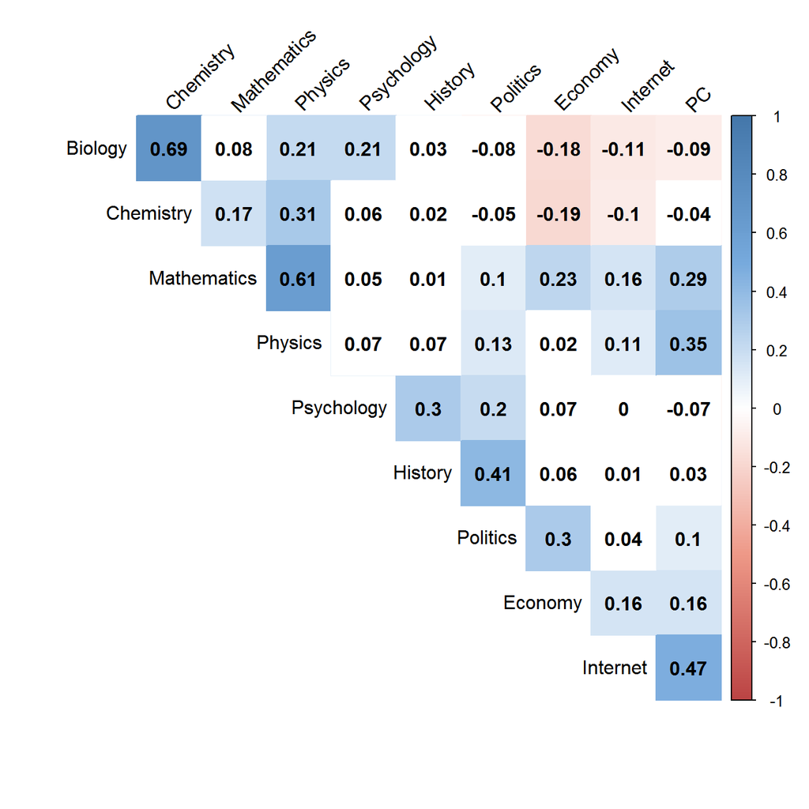

```r
# Plotting the correlations between first 10 variables along with the significance test
col <- colorRampPalette(c("#BB4444", "#EE9988", "#FFFFFF", "#77AADD", "#4477AA"))
corrplot(cor_matrix1, method = "color", col=col(200),
         type="upper", order="hclust",
         addCoef.col = "black", # Add coefficient of correlation
         tl.col="black", tl.srt=45, #Text label color and rotation
         # Combine with significance
         p.mat = p.mat, sig.level = 0.01, insig = "blank",
         # hide correlation coefficient on the principal diagonal
         diag=FALSE
         )
```

## 4.2 Second set of correlations

Interestingly, the Reading Poetry has a negative correlation with Cars. Actually I have to admit that I tried to look over only positive relationships from the histograms. Or now I understand that I might have done the exploring in that sense. The Poetry reading has an association also with Foreign Languages and Art Exhibition. The Geography shares only moderate relationships within this subset and its a shame that we can’t explore the correlations between the variables considering my initial hypothesis. It is almost the same situation with Medicine, Law, Religion, Outdoor activities and Dancing even though there are significant correlations between these variables. I just think that we can’t see the most important ones.

```r
library(knitr);library(corrplot)

# Presenting the second correlation matrix
cor_matrix2 <- cor(interests2) %>% round(digits = 2)
kable(cor_matrix2, format = "pandoc", digits = 2,  align="c", caption = 'Correlations between the 11th and 20th variable')
```

Correlations between the 11th and 20th variable

|  | rPoetry | Geography | Languages | Medicine | Law | Cars | Art | Religion | Outdoor | Dancing |
| --- | --- | --- | --- | --- | --- | --- | --- | --- | --- | --- |
| rPoetry | 1.00 | 0.13 | 0.32 | 0.18 | 0.09 | -0.31 | 0.39 | 0.24 | 0.13 | 0.18 |
| Geography | 0.13 | 1.00 | 0.25 | 0.09 | 0.19 | 0.08 | 0.16 | 0.12 | 0.19 | 0.10 |
| Languages | 0.32 | 0.25 | 1.00 | 0.13 | 0.20 | -0.08 | 0.24 | 0.15 | 0.14 | 0.19 |
| Medicine | 0.18 | 0.09 | 0.13 | 1.00 | 0.12 | 0.00 | 0.16 | 0.22 | 0.12 | 0.20 |
| Law | 0.09 | 0.19 | 0.20 | 0.12 | 1.00 | 0.19 | 0.12 | 0.10 | -0.03 | 0.12 |
| Cars | -0.31 | 0.08 | -0.08 | 0.00 | 0.19 | 1.00 | -0.10 | -0.05 | 0.01 | -0.07 |
| Art | 0.39 | 0.16 | 0.24 | 0.16 | 0.12 | -0.10 | 1.00 | 0.24 | 0.25 | 0.25 |
| Religion | 0.24 | 0.12 | 0.15 | 0.22 | 0.10 | -0.05 | 0.24 | 1.00 | 0.22 | 0.16 |
| Outdoor | 0.13 | 0.19 | 0.14 | 0.12 | -0.03 | 0.01 | 0.25 | 0.22 | 1.00 | 0.24 |
| Dancing | 0.18 | 0.10 | 0.19 | 0.20 | 0.12 | -0.07 | 0.25 | 0.16 | 0.24 | 1.00 |

```r
# mat : is a matrix of data
# ... : further arguments to pass to the native R cor.test function
cor.mtest <- function(mat, ...) {
    mat <- as.matrix(mat)
    n <- ncol(mat)
    p.mat<- matrix(NA, n, n)
    diag(p.mat) <- 0
    for (i in 1:(n - 1)) {
        for (j in (i + 1):n) {
            tmp <- cor.test(mat[, i], mat[, j], ...)
            p.mat[i, j] <- p.mat[j, i] <- tmp$p.value
        }
    }
  colnames(p.mat) <- rownames(p.mat) <- colnames(mat)
  p.mat
}

# matrix of the p-value of the correlation
p.mat <- cor.mtest(interests2)
kable((p.mat[, 1:10]), format = "pandoc", digits = 3,  align="c", caption = 'p-values, Significance test of correlations')
```

p-values, Significance test of correlations

|  | rPoetry | Geography | Languages | Medicine | Law | Cars | Art | Religion | Outdoor | Dancing |
| --- | --- | --- | --- | --- | --- | --- | --- | --- | --- | --- |
| rPoetry | 0.000 | 0.000 | 0.000 | 0.000 | 0.005 | 0.000 | 0.000 | 0.000 | 0.000 | 0.000 |
| Geography | 0.000 | 0.000 | 0.000 | 0.006 | 0.000 | 0.015 | 0.000 | 0.000 | 0.000 | 0.002 |
| Languages | 0.000 | 0.000 | 0.000 | 0.000 | 0.000 | 0.017 | 0.000 | 0.000 | 0.000 | 0.000 |
| Medicine | 0.000 | 0.006 | 0.000 | 0.000 | 0.001 | 0.924 | 0.000 | 0.000 | 0.000 | 0.000 |
| Law | 0.005 | 0.000 | 0.000 | 0.001 | 0.000 | 0.000 | 0.000 | 0.003 | 0.416 | 0.001 |
| Cars | 0.000 | 0.015 | 0.017 | 0.924 | 0.000 | 0.000 | 0.003 | 0.154 | 0.830 | 0.037 |
| Art | 0.000 | 0.000 | 0.000 | 0.000 | 0.000 | 0.003 | 0.000 | 0.000 | 0.000 | 0.000 |
| Religion | 0.000 | 0.000 | 0.000 | 0.000 | 0.003 | 0.154 | 0.000 | 0.000 | 0.000 | 0.000 |
| Outdoor | 0.000 | 0.000 | 0.000 | 0.000 | 0.416 | 0.830 | 0.000 | 0.000 | 0.000 | 0.000 |
| Dancing | 0.000 | 0.002 | 0.000 | 0.000 | 0.001 | 0.037 | 0.000 | 0.000 | 0.000 | 0.000 |

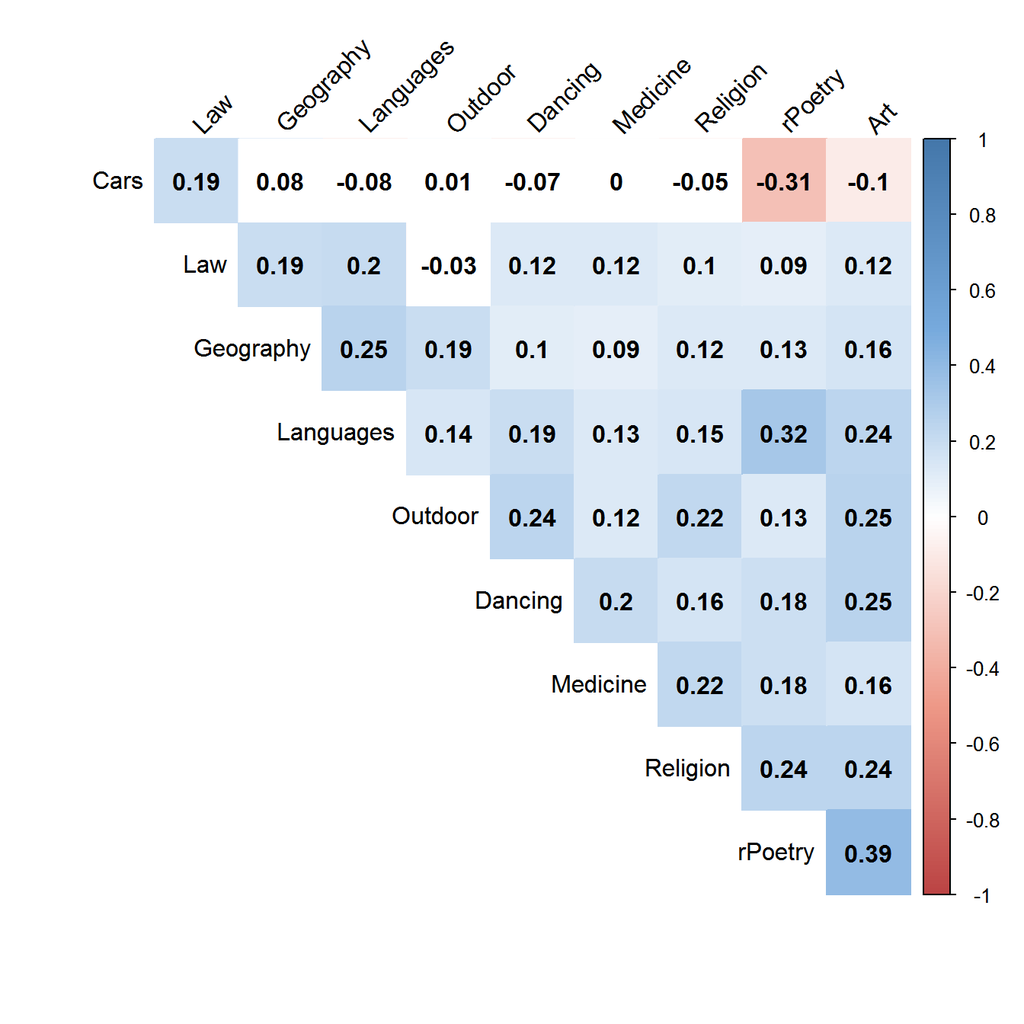

```r
# Plotting the correlations between 11th and 20th variables along with the significance test
col <- colorRampPalette(c("#BB4444", "#EE9988", "#FFFFFF", "#77AADD", "#4477AA"))
corrplot(cor_matrix2, method = "color", col=col(200),
         type="upper", order="hclust",
         addCoef.col = "black", # Add coefficient of correlation
         tl.col="black", tl.srt=45, #Text label color and rotation
         # Combine with significance
         p.mat = p.mat, sig.level = 0.01, insig = "blank",
         # hide correlation coefficient on the principal diagonal
         diag=FALSE
         )
```

## 4.3 Third set of correlations

Here the Playing instruments has a significant association with Poetry writing. This corresponds with my initial hypothesis. Both variables share a moderate but significant relation with the Gardening as intended. However we will see if the correlation is high enough regarding the PCA. Sport and leisure activities (sLeisure) doesn’t show any high correlations even though I imagined that it would share a higher relationship at least with pets, Socializing with friends and Sport at competitive level.

Interestingly but understandably the celebrity lifestyle is significantly related to shopping. I didn’t see this based on thei histograms but its undestandable considering their meaning. Science and technology (SciTec) seems to have moderate but significant relation with the Adrenaline sports. This was something what i doubted in my initial hypothesis. Then the Theatre show a significant association at least with Playing musical instrument.

```r
library(knitr); library(corrplot)

# Presenting the third correlation matrix
cor_matrix3 <- cor(interests3) %>% round(digits = 2)
kable(cor_matrix3, format = "pandoc", digits = 2,  align="c", caption = 'Correlations between the rest of the variables')
```

Correlations between the rest of the variables

|  | Instruments | wPoetry | sLeisure | sCompetitive | Gardening | Celebrities | Shopping | SciTec | Theatre | Social | sAdrenaline | Pets |
| --- | --- | --- | --- | --- | --- | --- | --- | --- | --- | --- | --- | --- |
| Instruments | 1.00 | 0.33 | 0.04 | 0.05 | 0.14 | -0.06 | -0.04 | 0.04 | 0.23 | 0.05 | 0.06 | -0.02 |
| wPoetry | 0.33 | 1.00 | -0.09 | 0.01 | 0.21 | 0.02 | 0.02 | 0.04 | 0.26 | -0.05 | 0.02 | 0.00 |
| sLeisure | 0.04 | -0.09 | 1.00 | 0.16 | 0.06 | 0.03 | 0.02 | 0.06 | -0.05 | 0.13 | 0.19 | 0.05 |
| sCompetitive | 0.05 | 0.01 | 0.16 | 1.00 | 0.09 | 0.03 | 0.03 | 0.14 | -0.05 | 0.12 | 0.38 | 0.06 |
| Gardening | 0.14 | 0.21 | 0.06 | 0.09 | 1.00 | 0.15 | 0.15 | 0.04 | 0.15 | 0.01 | 0.01 | 0.17 |
| Celebrities | -0.06 | 0.02 | 0.03 | 0.03 | 0.15 | 1.00 | 0.48 | -0.13 | 0.04 | 0.07 | -0.03 | 0.14 |
| Shopping | -0.04 | 0.02 | 0.02 | 0.03 | 0.15 | 0.48 | 1.00 | -0.10 | 0.19 | 0.20 | 0.00 | 0.20 |
| SciTec | 0.04 | 0.04 | 0.06 | 0.14 | 0.04 | -0.13 | -0.10 | 1.00 | 0.01 | 0.02 | 0.23 | 0.01 |
| Theatre | 0.23 | 0.26 | -0.05 | -0.05 | 0.15 | 0.04 | 0.19 | 0.01 | 1.00 | 0.18 | 0.01 | 0.10 |
| Social | 0.05 | -0.05 | 0.13 | 0.12 | 0.01 | 0.07 | 0.20 | 0.02 | 0.18 | 1.00 | 0.27 | 0.08 |
| sAdrenaline | 0.06 | 0.02 | 0.19 | 0.38 | 0.01 | -0.03 | 0.00 | 0.23 | 0.01 | 0.27 | 1.00 | 0.09 |
| Pets | -0.02 | 0.00 | 0.05 | 0.06 | 0.17 | 0.14 | 0.20 | 0.01 | 0.10 | 0.08 | 0.09 | 1.00 |

```r
# mat : is a matrix of data
# ... : further arguments to pass to the native R cor.test function
cor.mtest <- function(mat, ...) {
    mat <- as.matrix(mat)
    n <- ncol(mat)
    p.mat<- matrix(NA, n, n)
    diag(p.mat) <- 0
    for (i in 1:(n - 1)) {
        for (j in (i + 1):n) {
            tmp <- cor.test(mat[, i], mat[, j], ...)
            p.mat[i, j] <- p.mat[j, i] <- tmp$p.value
        }
    }
  colnames(p.mat) <- rownames(p.mat) <- colnames(mat)
  p.mat
}

# matrix of the p-value of the correlation
p.mat <- cor.mtest(interests3)
kable((p.mat[, 1:12]), format = "pandoc", digits = 3,  align="c", caption = 'p-values, Significance test of correlations')
```

p-values, Significance test of correlations

|  | Instruments | wPoetry | sLeisure | sCompetitive | Gardening | Celebrities | Shopping | SciTec | Theatre | Social | sAdrenaline | Pets |
| --- | --- | --- | --- | --- | --- | --- | --- | --- | --- | --- | --- | --- |
| Instruments | 0.000 | 0.000 | 0.185 | 0.116 | 0.000 | 0.086 | 0.246 | 0.271 | 0.000 | 0.119 | 0.067 | 0.619 |
| wPoetry | 0.000 | 0.000 | 0.008 | 0.849 | 0.000 | 0.550 | 0.656 | 0.264 | 0.000 | 0.138 | 0.552 | 0.882 |
| sLeisure | 0.185 | 0.008 | 0.000 | 0.000 | 0.091 | 0.370 | 0.470 | 0.092 | 0.124 | 0.000 | 0.000 | 0.135 |
| sCompetitive | 0.116 | 0.849 | 0.000 | 0.000 | 0.009 | 0.454 | 0.416 | 0.000 | 0.113 | 0.000 | 0.000 | 0.102 |
| Gardening | 0.000 | 0.000 | 0.091 | 0.009 | 0.000 | 0.000 | 0.000 | 0.226 | 0.000 | 0.702 | 0.830 | 0.000 |
| Celebrities | 0.086 | 0.550 | 0.370 | 0.454 | 0.000 | 0.000 | 0.000 | 0.000 | 0.248 | 0.051 | 0.397 | 0.000 |
| Shopping | 0.246 | 0.656 | 0.470 | 0.416 | 0.000 | 0.000 | 0.000 | 0.003 | 0.000 | 0.000 | 0.947 | 0.000 |
| SciTec | 0.271 | 0.264 | 0.092 | 0.000 | 0.226 | 0.000 | 0.003 | 0.000 | 0.739 | 0.512 | 0.000 | 0.658 |
| Theatre | 0.000 | 0.000 | 0.124 | 0.113 | 0.000 | 0.248 | 0.000 | 0.739 | 0.000 | 0.000 | 0.880 | 0.004 |
| Social | 0.119 | 0.138 | 0.000 | 0.000 | 0.702 | 0.051 | 0.000 | 0.512 | 0.000 | 0.000 | 0.000 | 0.024 |
| sAdrenaline | 0.067 | 0.552 | 0.000 | 0.000 | 0.830 | 0.397 | 0.947 | 0.000 | 0.880 | 0.000 | 0.000 | 0.008 |
| Pets | 0.619 | 0.882 | 0.135 | 0.102 | 0.000 | 0.000 | 0.000 | 0.658 | 0.004 | 0.024 | 0.008 | 0.000 |

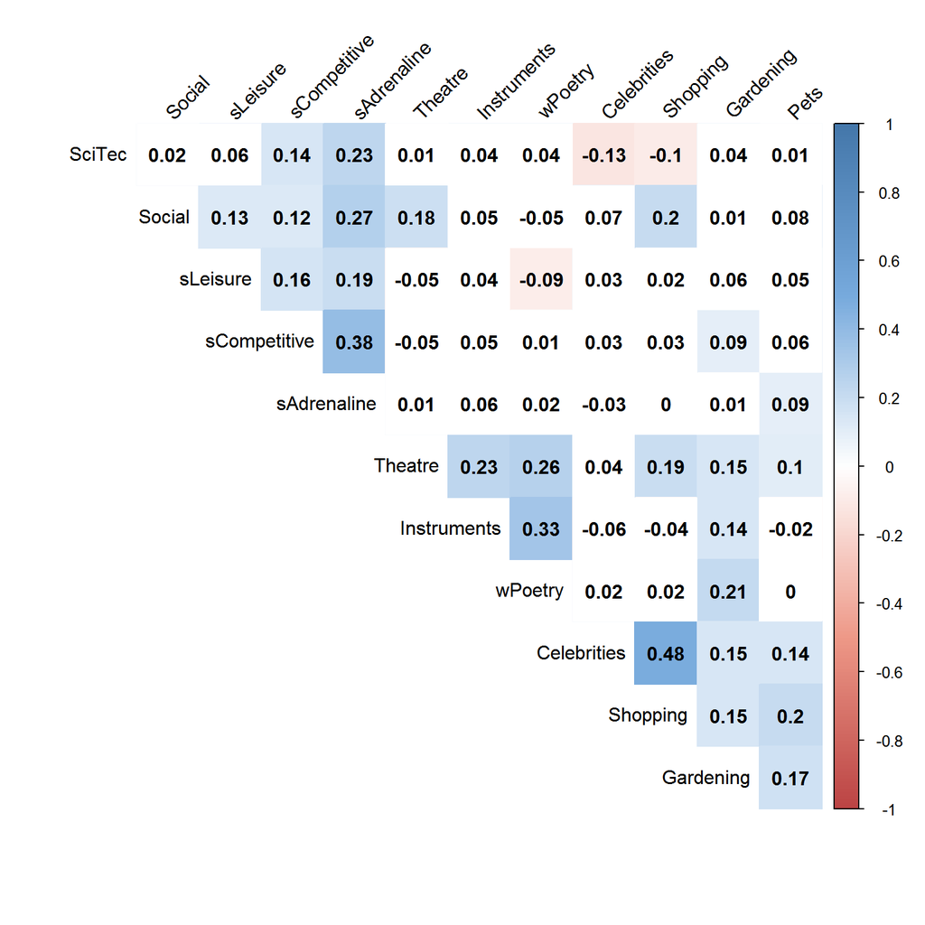

```r
# Plotting the correlations between the rest of the variables along with the significance test
col <- colorRampPalette(c("#BB4444", "#EE9988", "#FFFFFF", "#77AADD", "#4477AA"))
corrplot(cor_matrix3, method = "color", col=col(200),
         type="upper", order="hclust",
         addCoef.col = "black", # Add coefficient of correlation
         tl.col="black", tl.srt=45, #Text label color and rotation
         # Combine with significance
         p.mat = p.mat, sig.level = 0.01, insig = "blank",
         # hide correlation coefficient on the principal diagonal
         diag=FALSE
         )
```

## 4.4 One way to present all the correlations

Actually, I found a pretty nice solution to present all the correlations of young people’s interests, adopted [here](http://geog.uoregon.edu/GeogR/topics/pca.html).

This is a network of line segments, which are drawn to illustrate the strenght and sign of the correlations between each pair of variables. The layout arranges the nodes in a way that locates more highly correlated variables closer to one another. Additionally the the red color indicates positive and the the blue indicates negative correlations.

By means of this network presentation we can examine simultaneously the whole data. For example, now we can see that the Chemistry, Biology and Medicine are highly correlated to each other. Then there are Mathematics, Physics, PC and SciTec which are also correlated to one another.

Considering the upcoming Principal Component Analysis, it is also important to perceive the variables with much lower correlations. For example, it seems that sLeisure (Sport and leisure activities) and especially the Pets are far away from any centrum.

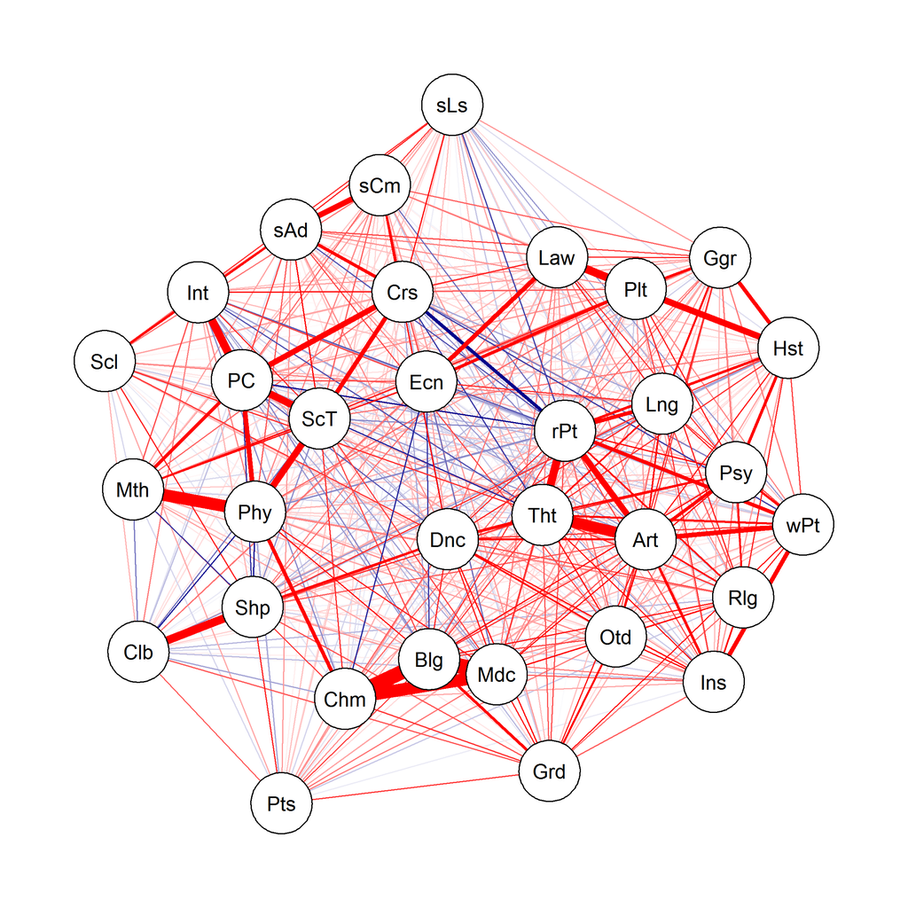

```r
# http://geog.uoregon.edu/GeogR/topics/pca.html
library(qgraph)
qgraph(cor(interests), layout="spring", posCol="red", negCol="darkblue")
```

# 5 Principal Component Analysis

Principal Component Analysis (PCA) can be seen as a method of extracting important variables from a large set of variables in a dataset. It extracts low dimensional set of features from a high dimensional dataset with a purpose to capture as much information as possible. [Analytics Vidhya Content Team, Marc 21, 2016](https://www.analyticsvidhya.com/blog/2016/03/practical-guide-principal-component-analysis-python/).

The dataset of **Young people’s interests** contains multitude dimensions corresponding to 878 observations (n) x 32 variables or predictors (p). We could examine the relationships by means of the scatter plots but there would be as many as **p(p-1)/2** i.e. **496 plots** to explore. This actually makes visible the meaning of PCA, since it allows to deal with high dimensional data.

A principal component can be seen as a normalized linear combination or the original predictors in a dataset. The first principal component captures the most of the variance in the dataset. The second principal component captures the maximum variance of the dataset that are uncorrelated with the first component. Futhermore, all succeeding principal components follow the similar concept. They capture the remaining variance without being correlated with the previous component. Note that capturing amount of variance corresponds to capturing amount of information.

**PCA is (always) performed with a numeric and standardized dataset!**

Thus, I’m going to scale my data first and show briefly the distributions of the standardized data. After that I will perform the actual analysis, show the summary and print the first biplot. Then I will evaluate the results by means of some numerical and graphical methods.

## 5.1 Scaling the data of interests

I had some problems to use the function “scale()” combined to “ggplot()”. I noticed that the scale function converts the data as ‘matrix’ which is not applicable with ggplot. I didn’t find any solution to use “scale” and “ggplot” simultaneously and I definitely didn’t want to skip the plotting part. Thus I found another solution from [clusterSim package](https://cran.r-project.org/web/packages/clusterSim/clusterSim.pdf) which allows to standardize the data while it stays as a data frame. The package and its fuction called “data.Normalization” contains multiple transformation possibilities but I chose the formula (n1) corresponding to the “scale” function, i.e. **((x-mean)/sd)**.

Inside the chunk below you can notice that I formed also the “scale() function” but I don’t use it, at least not just yet. I left it there in case someone want to verify the similarities of both methods by printing the summaries.

Below you can find the summary of scaled data (data.Normalization) and corresponding histograms. Now you can notice that the mean of every variable is zero and the observations varies on both sides of zero. This means that the different distributions are now more comparable for the further purposes.

```r
library(clusterSim); library(tidyr); library(ggplot2)

# Standardizing the data of interests
std_interests <- scale(interests) # This makes the data as a 'Matrix' and ggplot can't read it

# Scaling/ standardizing the data of interests and printing the summary
norm_interests <- data.Normalization(interests, type = "n1", normalization = "columns")
summary(norm_interests)
```

```
##     History          Psychology          Politics        Mathematics
##  Min.   :-1.7406   Min.   :-1.68515   Min.   :-1.2340   Min.   :-1.0183
##  1st Qu.:-0.9520   1st Qu.:-0.88711   1st Qu.:-1.2340   1st Qu.:-1.0183
##  Median :-0.1635   Median :-0.08907   Median :-0.4694   Median :-0.2763
##  Mean   : 0.0000   Mean   : 0.00000   Mean   : 0.0000   Mean   : 0.0000
##  3rd Qu.: 0.6251   3rd Qu.: 0.70896   3rd Qu.: 1.0598   3rd Qu.: 0.4656
##  Max.   : 1.4137   Max.   : 1.50700   Max.   : 1.8244   Max.   : 1.9495
##     Physics            Internet             PC              Economy
##  Min.   :-0.87792   Min.   :-3.4737   Min.   :-1.61764   Min.   :-1.224
##  1st Qu.:-0.87792   1st Qu.:-0.1907   1st Qu.:-0.85853   1st Qu.:-1.224
##  Median :-0.06739   Median :-0.1907   Median :-0.09943   Median :-0.478
##  Mean   : 0.00000   Mean   : 0.0000   Mean   : 0.00000   Mean   : 0.000
##  3rd Qu.: 0.74314   3rd Qu.: 0.9036   3rd Qu.: 0.65968   3rd Qu.: 1.013
##  Max.   : 2.36421   Max.   : 0.9036   Max.   : 1.41878   Max.   : 1.758
##     Biology          Chemistry          rPoetry          Geography
##  Min.   :-1.2008   Min.   :-0.8454   Min.   :-1.4468   Min.   :-1.64998
##  1st Qu.:-1.2008   1st Qu.:-0.8454   1st Qu.:-0.7768   1st Qu.:-0.86564
##  Median :-0.4757   Median :-0.1112   Median :-0.1068   Median :-0.08129
##  Mean   : 0.0000   Mean   : 0.0000   Mean   : 0.0000   Mean   : 0.00000
##  3rd Qu.: 0.9745   3rd Qu.: 0.6230   3rd Qu.: 1.2332   3rd Qu.: 0.70305
##  Max.   : 1.6996   Max.   : 2.0914   Max.   : 1.2332   Max.   : 1.48739
##    Languages          Medicine            Law               Cars
##  Min.   :-2.4688   Min.   :-1.1071   Min.   :-1.0062   Min.   :-1.1700
##  1st Qu.:-0.6979   1st Qu.:-1.1071   1st Qu.:-1.0062   1st Qu.:-1.1700
##  Median : 0.1876   Median :-0.3757   Median :-0.2001   Median :-0.4669
##  Mean   : 0.0000   Mean   : 0.0000   Mean   : 0.0000   Mean   : 0.0000
##  3rd Qu.: 1.0730   3rd Qu.: 0.3557   3rd Qu.: 0.6059   3rd Qu.: 0.9394
##  Max.   : 1.0730   Max.   : 1.8185   Max.   : 2.2180   Max.   : 1.6425
##       Art             Religion          Outdoor           Dancing
##  Min.   :-1.2152   Min.   :-0.9577   Min.   :-2.2216   Min.   :-1.0035
##  1st Qu.:-1.2152   1st Qu.:-0.9577   1st Qu.:-0.5601   1st Qu.:-1.0035
##  Median :-0.4558   Median :-0.2015   Median : 0.2706   Median :-0.3059
##  Mean   : 0.0000   Mean   : 0.0000   Mean   : 0.0000   Mean   : 0.0000
##  3rd Qu.: 1.0630   3rd Qu.: 0.5547   3rd Qu.: 1.1013   3rd Qu.: 0.3917
##  Max.   : 1.8224   Max.   : 2.0671   Max.   : 1.1013   Max.   : 1.7869
##   Instruments         wPoetry           sLeisure        sCompetitive
##  Min.   :-0.8719   Min.   :-0.6911   Min.   :-1.7219   Min.   :-1.5089
##  1st Qu.:-0.8719   1st Qu.:-0.6911   1st Qu.:-1.0084   1st Qu.:-0.8455
##  Median :-0.2108   Median :-0.6911   Median : 0.4185   Median :-0.1821
##  Mean   : 0.0000   Mean   : 0.0000   Mean   : 0.0000   Mean   : 0.0000
##  3rd Qu.: 1.1113   3rd Qu.: 0.8648   3rd Qu.: 1.1319   3rd Qu.: 1.1447
##  Max.   : 1.7724   Max.   : 2.4207   Max.   : 1.1319   Max.   : 1.1447
##    Gardening        Celebrities         Shopping           SciTec
##  Min.   :-0.7802   Min.   :-1.0585   Min.   :-1.7635   Min.   :-1.7589
##  1st Qu.:-0.7802   1st Qu.:-1.0585   1st Qu.:-0.9843   1st Qu.:-0.9770
##  Median :-0.7802   Median :-0.2722   Median :-0.2050   Median :-0.1950
##  Mean   : 0.0000   Mean   : 0.0000   Mean   : 0.0000   Mean   : 0.0000
##  3rd Qu.: 0.7430   3rd Qu.: 0.5140   3rd Qu.: 0.5742   3rd Qu.: 0.5869
##  Max.   : 2.7015   Max.   : 2.0865   Max.   : 1.3535   Max.   : 1.3688
##     Theatre             Social         sAdrenaline           Pets
##  Min.   :-1.52708   Min.   :-3.4737   Min.   :-1.3764   Min.   :-1.5113
##  1st Qu.:-0.77256   1st Qu.:-0.7554   1st Qu.:-0.6659   1st Qu.:-0.8637
##  Median :-0.01805   Median : 0.6037   Median : 0.0445   Median : 0.4315
##  Mean   : 0.00000   Mean   : 0.0000   Mean   : 0.0000   Mean   : 0.0000
##  3rd Qu.: 0.73647   3rd Qu.: 0.6037   3rd Qu.: 0.7549   3rd Qu.: 1.0791
##  Max.   : 1.49099   Max.   : 0.6037   Max.   : 1.4654   Max.   : 1.0791
```

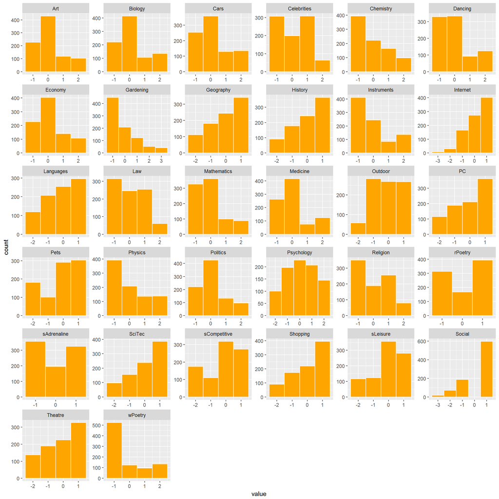

```r
# Plotting the data
gather(norm_interests) %>% ggplot(aes(value)) + facet_wrap("key", scales = "free") + geom_histogram(color = "white", fill = "orange", binwidth = 1)
```

## 5.2 Performing the PCA and presenting the first biplot

There are two slightly different methods to perform the PCA: the Eigenvalue Decomposition (princomp) and the Singular Value Decomposition (prcomp). Usually the latter is preferred for its numerical accuracy [STHDA, prcomp vs. princomp](http://www.sthda.com/english/wiki/principal-component-analysis-in-r-prcomp-vs-princomp-r-software-and-data-mining). Thus the Singular Value Decomposition method is used here.

The summary method shows the importance of the principal components. The first row describes the standard deviation associated with each component. The second row shows the proportion of the variance in the data explained by each component while the third row describes the cumulative proportion of explained variance.

We aim to find the components which explain the maximum variance. This is because, we want to retain as much information as possible using these components. Thus, the higher is the explained variance, the higher will be the information contained in those components.

**The summary below** suggests that the first principal component has captured only 13.1% of the total variance from the data of interests. The second principal component has captures 10.2% and the third 8% and so on. You can also see that the variance is divided to several other components suggesting that the data is still quite multidimensional. However, this was expected already according to my initial hypotheses where I assumed that the data will contain at least 7 dimensions. I think that this is also evident when we have a large amount of variables with multiple features.

```r
# Performing the PCA with Singular Value Decomposition (SVD) method
pca_interests <- prcomp(norm_interests)
pca2_interests <- prcomp(std_interests) # just for testing purposes

# Printing a summary of PCA
summary(pca_interests)
```

```
## Importance of components:
##                          PC1    PC2     PC3    PC4    PC5    PC6     PC7
## Standard deviation     2.047 1.8101 1.60036 1.4664 1.2662 1.1852 1.07069
## Proportion of Variance 0.131 0.1024 0.08004 0.0672 0.0501 0.0439 0.03582
## Cumulative Proportion  0.131 0.2333 0.31338 0.3806 0.4307 0.4746 0.51040
##                            PC8     PC9    PC10    PC11    PC12    PC13
## Standard deviation     1.05722 1.04538 1.00728 0.95917 0.93928 0.93096
## Proportion of Variance 0.03493 0.03415 0.03171 0.02875 0.02757 0.02708
## Cumulative Proportion  0.54533 0.57948 0.61118 0.63993 0.66750 0.69459
##                           PC14    PC15    PC16    PC17    PC18    PC19
## Standard deviation     0.89323 0.87398 0.85295 0.83168 0.80301 0.78328
## Proportion of Variance 0.02493 0.02387 0.02274 0.02162 0.02015 0.01917
## Cumulative Proportion  0.71952 0.74339 0.76613 0.78774 0.80789 0.82706
##                           PC20    PC21   PC22    PC23   PC24    PC25
## Standard deviation     0.76811 0.74015 0.7266 0.71087 0.7088 0.68287
## Proportion of Variance 0.01844 0.01712 0.0165 0.01579 0.0157 0.01457
## Cumulative Proportion  0.84550 0.86262 0.8791 0.89491 0.9106 0.92518
##                           PC26    PC27    PC28    PC29    PC30    PC31
## Standard deviation     0.65204 0.64432 0.60951 0.59623 0.55018 0.53847
## Proportion of Variance 0.01329 0.01297 0.01161 0.01111 0.00946 0.00906
## Cumulative Proportion  0.93847 0.95144 0.96305 0.97416 0.98362 0.99268
##                           PC32
## Standard deviation     0.48403
## Proportion of Variance 0.00732
## Cumulative Proportion  1.00000
```

**Let’s take a look at the first biplot to demonstrate the summary above.** The figure plots the first two principal components and represents both the principal component scores (n = 878) and the loading vectors (p = 32) in a sigle biplot display. Thus the numbers in the biplot illustrate the individuals (i.e. principal component scores) and the arrows indicate the variables in the first two loading vectors.

Above I concluded that the data of interests is still highly multidimensional after performing the PCA. Here I think that its even more evident after running the biplot which seems to be quite messy. However, we can interpret few things from the plot. If I concentrate to the loading vectors (i.e. the variables), the orange arrows and their closeness to other arrows implies the correlations between the variables. The closer the arrows are the more correlated they are with each other. For example the interest toward PC and Cars seem to be higly and positive correlated. Another phenomenon is that the orthogonal arrows suggest negative correlation between the variables. For example interest toward Cars and rPoetry (Poetry reading) share a negative correlation (r = -0.31)

To conclude thus far, the biplot shows more positive than negative correlation between variables and the interpretation, regarding the dimension reduction, is almost impossible based on the available information. Thus I need some additional methods to go further.

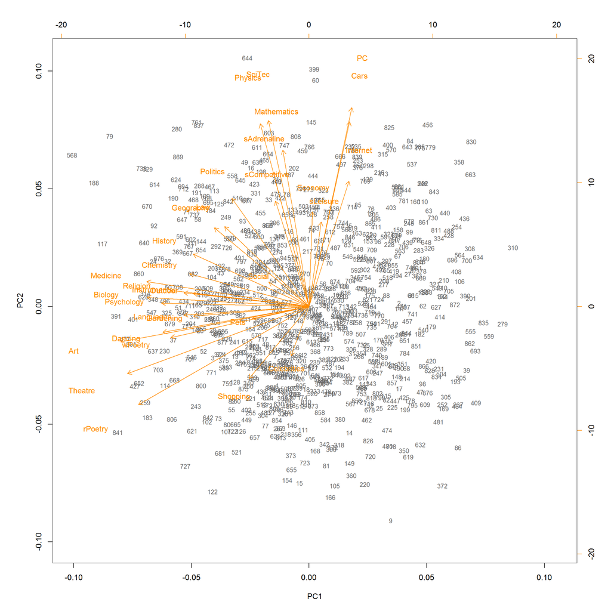

```r
biplot(pca_interests, cex = c(0.8, 1), col = c("dimgrey", "darkorange"))
```

## 5.3 Dimensions to retain

There are two popular criteria to evaluate the proper amount of principal components. These are the [Kaiser criterion and Cattell’s Scree test](http://www.uta.edu/faculty/sawasthi/Statistics/stfacan.html). They both use the eigenvalues of principal conponents to propose the best amount of dimensions.

The Kaiser criterion suggests to retain dimensions with eigenvalues greater than one. Instead, the Scree test is a graphical method to plot the eigenvalues. Its criterion suggest to find a proper amount of dimensions when the smooth decrease of the line appears.

**Let’s take a look at the eigevalues first.** The table below consists also the variances which I interpreted earlier, thus I’m going to concentrate the eigenvalues. Note that I retained the values of first 12 dimension. Regarding the Kaiser criterion, i.e. eigenvalue > 1, it seems that 10 of the the printed dimensions could be meaningful. Let’s take a look at the Scree test, if the results will be similar.

```r
library(factoextra); library(knitr)

eig.val <- get_eigenvalue(pca_interests)
kable(round(eig.val[1:12,], digits = 3), align="c", caption = 'Eigenvalues and variances')
```

Eigenvalues and variances

|  | eigenvalue | variance.percent | cumulative.variance.percent |
| --- | --- | --- | --- |
| Dim.1 | 4.190 | 13.095 | 13.095 |
| Dim.2 | 3.276 | 10.239 | 23.334 |
| Dim.3 | 2.561 | 8.004 | 31.338 |
| Dim.4 | 2.150 | 6.720 | 38.058 |
| Dim.5 | 1.603 | 5.010 | 43.068 |
| Dim.6 | 1.405 | 4.390 | 47.457 |
| Dim.7 | 1.146 | 3.582 | 51.040 |
| Dim.8 | 1.118 | 3.493 | 54.533 |
| Dim.9 | 1.093 | 3.415 | 57.948 |
| Dim.10 | 1.015 | 3.171 | 61.118 |
| Dim.11 | 0.920 | 2.875 | 63.993 |
| Dim.12 | 0.882 | 2.757 | 66.750 |

SCREE PLOT OF EIGENVALUES

**The Scree test** method returns a plot of the variances (y-axis) associated with the principal components (x-axis). The Scree plot can be useful to decide how many component to retain for further analysis.

I retained the above suggested 10 dimensions for the purpose of the Scree plot below. But what does it imply? We can perceive that there are no obvious bendings to help us to make the decision. However, after seventh dimension the line becomes more steady. Thus I will propose that at least the last 3 dimensions could be irrelevant.

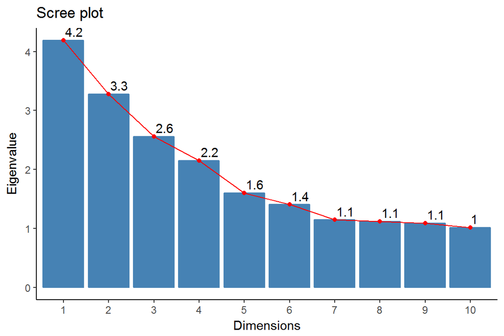

```r
library(factoextra)

fviz_screeplot(pca_interests, ncp=10, choice="eigenvalue", addlabels=TRUE, hjust = -0.1, linecolor ="red") + theme_classic()
```

SCREE PLOT OF EXPLAINED VARIANCE

After the eigenvalues we can evaluate the dimensions to retain also by means of the explained variance. According to [sthda guidelines](http://www.sthda.com/english/wiki/principal-component-analysis-in-r-prcomp-vs-princomp-r-software-and-data-mining#use-the-r-function-prcomp-for-pca) a good dimension reduction is achieved when the first few PCs account for a large proportion of the variablity (80-90%).

Below you can see a scree plot of variance explained by first 10 dimensions. Note that I showed the variances also in the beginning of this chapter. However, regarding the guidelines above I have to doubt my results of the dimension reduction since the first 10 dimensions count around 60% of the total variance.

I have to say that I’m slightly confused therefore I’m going to evaluate the principal component loadings after this.

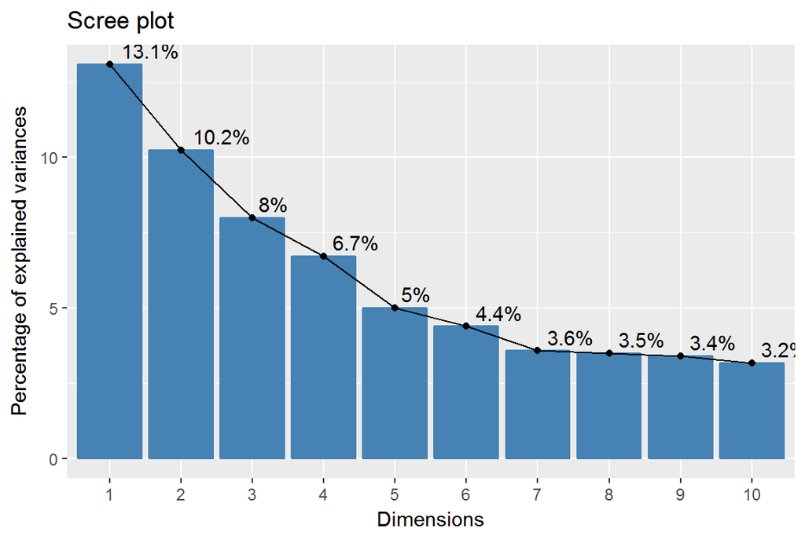

```r
library(factoextra)

fviz_screeplot(pca_interests, ncp=10, addlabels=TRUE, hjust = -0.2) + theme_gray()
```

## 5.4 Principal component loadings

The rotation measure in prcomp() provides the principal component loadings. Each column of rotation matrix contains the principal component loading vector. Accordin to this [stackexchange conversation](http://stats.stackexchange.com/questions/59213/how-to-compute-varimax-rotated-principal-components-in-r), the term “rotation” is slightly misleading concept, since it indicates more to Factor Analysis. The rotation (in Factor Analysis) is usually applied to loadings, not to eigenvectors of the covariance matrix, which is used to provide the loadings of prcomp(), as far as I know.

TABLE OF LOADINGS

Underneath we can see the table of principal component loadings. I printed the loadings of 10 dimension, since I couldn’t make any strict decisions by means of the dimension retaining process. It seems that we have a lot of “noise” since most of the loadings are quite. Additionally, there is no clear structure or distinction where the variables load the most. For example the History loads to both 4th and 6th components. Politics loads to 3th and 5th dimensions. Some of the variables load more strongly to one dimension, e.g. Physics (to 2nd comp), PC (to 2nd comp), Economy (to 3rd comp), Biology and Chemistry (both to 3rd comp), and few others.

Next I’m going to explore two different kind of biplot to help me go further. The first plot has the same structure and same features as the biplot presented earlier. Here I made a larger plot to examine the relationships more carefully.

```r
# Loadings restricted to 10 components
rotation <- round(pca_interests$rotation[, 1:10], digits = 3)
kable(rotation)
```

|  | PC1 | PC2 | PC3 | PC4 | PC5 | PC6 | PC7 | PC8 | PC9 | PC10 |
| --- | --- | --- | --- | --- | --- | --- | --- | --- | --- | --- |
| History | -0.193 | 0.098 | -0.190 | 0.238 | -0.133 | 0.239 | -0.166 | 0.165 | -0.176 | -0.050 |
| Psychology | -0.246 | 0.007 | -0.075 | 0.114 | -0.109 | -0.029 | 0.102 | -0.060 | -0.205 | 0.185 |
| Politics | -0.129 | 0.204 | -0.264 | 0.197 | -0.270 | 0.152 | -0.069 | -0.115 | -0.032 | -0.039 |
| Mathematics | -0.044 | 0.294 | 0.124 | 0.132 | 0.014 | -0.313 | 0.246 | -0.244 | 0.067 | -0.356 |
| Physics | -0.081 | 0.344 | 0.241 | 0.136 | 0.028 | -0.156 | 0.162 | -0.147 | -0.117 | -0.160 |
| Internet | 0.066 | 0.236 | -0.120 | -0.092 | 0.017 | -0.402 | -0.139 | 0.361 | 0.064 | 0.126 |
| PC | 0.071 | 0.374 | -0.001 | 0.042 | 0.130 | -0.290 | -0.151 | 0.125 | -0.057 | 0.188 |
| Economy | 0.006 | 0.178 | -0.306 | -0.022 | -0.207 | -0.181 | 0.204 | -0.247 | 0.184 | -0.197 |
| Biology | -0.270 | 0.017 | 0.375 | -0.151 | -0.221 | 0.022 | -0.001 | 0.097 | 0.088 | 0.058 |
| Chemistry | -0.199 | 0.062 | 0.421 | -0.090 | -0.232 | 0.032 | 0.078 | 0.061 | 0.076 | 0.037 |
| rPoetry | -0.284 | -0.185 | -0.061 | 0.174 | -0.023 | -0.071 | 0.025 | 0.163 | -0.086 | -0.108 |
| Geography | -0.158 | 0.148 | -0.152 | 0.069 | -0.019 | 0.222 | -0.237 | 0.251 | 0.307 | -0.105 |
| Languages | -0.208 | -0.016 | -0.218 | 0.029 | -0.046 | -0.111 | 0.149 | 0.274 | 0.342 | 0.120 |
| Medicine | -0.270 | 0.047 | 0.315 | -0.118 | -0.264 | 0.067 | 0.020 | 0.074 | 0.130 | 0.175 |
| Law | -0.141 | 0.150 | -0.282 | -0.009 | -0.360 | 0.112 | 0.008 | -0.151 | -0.016 | -0.036 |
| Cars | 0.067 | 0.348 | -0.057 | -0.170 | 0.002 | 0.093 | -0.099 | 0.017 | -0.103 | 0.057 |
| Art | -0.314 | -0.066 | -0.096 | 0.049 | 0.202 | -0.091 | 0.066 | 0.049 | -0.180 | -0.047 |
| Religion | -0.229 | 0.030 | 0.012 | 0.168 | 0.042 | -0.047 | -0.119 | -0.077 | 0.238 | 0.005 |
| Outdoor | -0.193 | 0.025 | 0.022 | -0.097 | 0.335 | 0.073 | -0.175 | 0.131 | 0.229 | -0.375 |
| Dancing | -0.244 | -0.049 | -0.074 | -0.229 | 0.102 | -0.014 | 0.137 | -0.293 | 0.218 | 0.072 |
| Instruments | -0.209 | 0.026 | 0.011 | 0.082 | 0.359 | -0.086 | -0.063 | -0.161 | 0.136 | 0.225 |
| wPoetry | -0.230 | -0.058 | -0.066 | 0.166 | 0.191 | -0.114 | -0.196 | -0.219 | -0.183 | 0.324 |
| sLeisure | 0.020 | 0.159 | -0.043 | -0.222 | 0.139 | 0.105 | -0.092 | 0.101 | 0.156 | -0.240 |
| sCompetitive | -0.056 | 0.198 | -0.044 | -0.241 | 0.144 | 0.342 | 0.008 | -0.294 | 0.013 | 0.199 |
| Gardening | -0.193 | -0.018 | 0.087 | -0.176 | 0.087 | -0.101 | -0.429 | -0.244 | -0.078 | -0.221 |
| Celebrities | -0.030 | -0.093 | -0.177 | -0.351 | -0.182 | -0.291 | -0.227 | -0.102 | -0.007 | 0.106 |
| Shopping | -0.100 | -0.136 | -0.173 | -0.400 | -0.150 | -0.244 | 0.007 | 0.011 | -0.032 | 0.064 |
| SciTec | -0.068 | 0.350 | 0.103 | 0.032 | 0.002 | -0.062 | -0.059 | 0.175 | -0.223 | 0.160 |
| Theatre | -0.303 | -0.126 | -0.089 | 0.020 | 0.141 | -0.075 | 0.241 | 0.124 | -0.217 | -0.145 |
| Social | -0.067 | 0.046 | -0.132 | -0.264 | 0.162 | 0.040 | 0.466 | 0.242 | -0.117 | 0.016 |
| sAdrenaline | -0.060 | 0.253 | -0.075 | -0.222 | 0.210 | 0.306 | 0.177 | 0.006 | -0.108 | 0.121 |
| Pets | -0.095 | -0.023 | 0.019 | -0.257 | -0.090 | 0.023 | -0.164 | 0.071 | -0.460 | -0.342 |

```r
rotation2 <- round(pca2_interests$rotation[, 1:10], digits = 2) # Just for testing purposes
```

ENLARGEMENT OF THE BASIC BIPLOT

Now the figure is larger and we can see for example the coordinate system. One feature of the biplot what I didn’t mention earlier is that the lenght of the arrows measures the contribution of the variables by means of their loadings. According to this information we can notice that there is at least 3 different group with relative high contribution.

**From the upper right corner** the PC and Cars definitely belong to the same dimension. Their arrows are long and they are almost on top of each other suggesting high correlation between them. The Internet indicates to the same direction with a lower contribution. Economy and sLeisure (Sport and leisure activities) may point to the same direction but with much lower contribution. Regarding this, the latter variables may not include to this or any dimension.

**The second group** contains at least the Physics and SciTec (Science and Technology) with relative high contribution also to second dimension within the biplot presentation. The Mathematics, sAdrenaline and sCompetitive may include to the same dimension but with lower contribution.

**Then there are some “middle” variables** which don’t share so high groupping features, thus its more difficult to interpret where these variables belong. However, iti starting to look that at least the Pets and Social (Solializing with friends) don’t belong to any principal component.

**From the lower left corner** we find at least one meaningful group including Art Exhibitions, Theatre and Poetry Reading. The Dancing and Poetry Reading may also include to this dimension.

I think that we can find at least one dimension including Medicine, Biology, Psychology and maybe Religion, Instruments and Outdoor Activities.

To conlcude thus far I think its clear that the variables with the highest contribution share also some similar features. For example Art, Theatre and Poetry Reading, and even Dancing and Poetry writing are all representing interest relating to arts. The phenomenon is equivalent with Medicine, Biology and Psychology, because they all indicate interest toward people and their well-being. Furthermore the SciTec, Physics and Mathematics depict the features of mathematical and technical issues. And finally the PC and Cars indicate both to different kind of technical features comparing to former group.

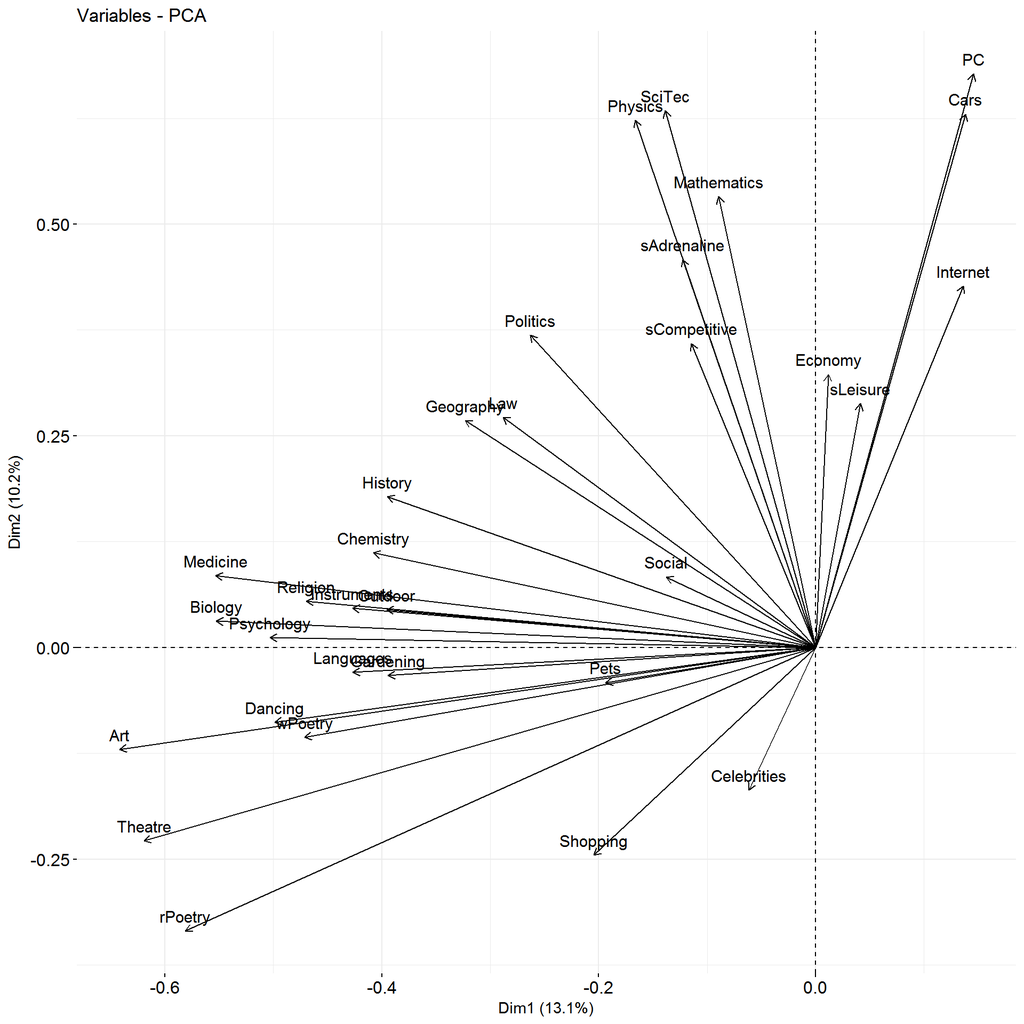

```r
library(FactoMineR)

biplot1 <- fviz_pca_var(pca_interests)
biplot1
```

BIPLOT WITH FACTOMINER

For the more visual purposes I attached the FactoMiner and factoextra packages. FactoMiner has its own function for Principal Component Analysis, “PCA()”. Note that I used the factoextra earlier to visualize the Scree plots but now it seems that the biplot visualization works better with its own function. For this reason I performed the Principal Component Analysis again. I wanted to understand some of the mathematics behind the package and therefore I have some additional “testing codes” inside the chunk below.

For some reason the method turns the arrows the other way round but it doesn’t change the results. From this biplot you can observe basically the same interpretations as I wrote above but with additional coloring effects. Note that I have set the “midpoint” relative low to present the variation within this data. Here it is more evident that the variables with very light colour do not have high contribution to any dimension.

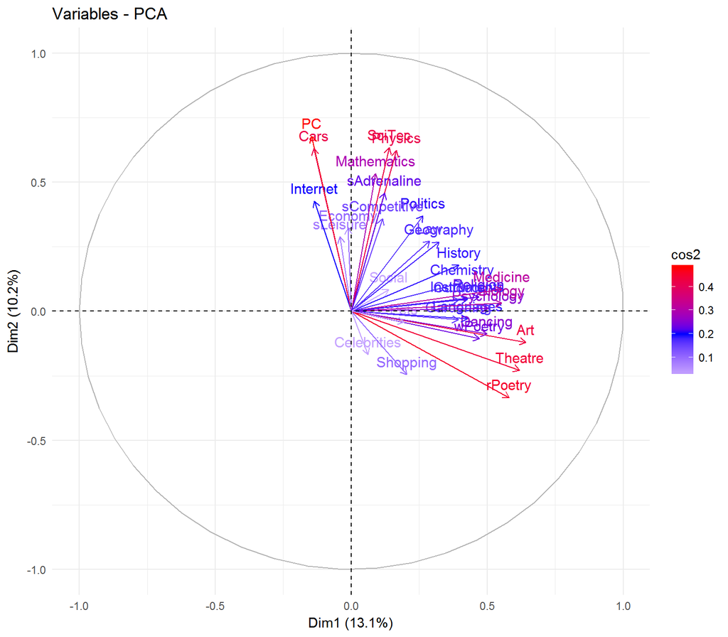

```r
library(FactoMineR); library(factoextra); library(knitr)

# http://www.sthda.com/english/wiki/principal-component-analysis-how-to-reveal-the-most-important-variables-in-your-data-r-software-and-data-mining#at_pco=smlwn-1.0&at_si=58bbc17c84dcd355&at_ab=per-2&at_pos=0&at_tot=1

PCA_interests <- PCA(interests, graph = FALSE)

eig.val2 <- PCA_interests$eig # Just verifying that this gives the same eigenvalues than prcomp() and it does

PCA.var <- PCA_interests$var # different results for variables

# The squared loadings, i.e. variance^2
cos2.var <- PCA_interests$var$cos2 # These are the loadings, corresponding to rotate function in procomp()

# Biplot of loadings
biplot2 <- fviz_pca_var(PCA_interests, col.var="cos2") + scale_color_gradient2(low="white", mid="blue", high="red", midpoint=0.2) + theme_minimal()

biplot2
```

## 5.5 Conclusions of the first PCA part

It is evident that the data of interests contains at least 3 clear dimensions while their exact content of variables is unclear. Secondly, it is not so clear how many other dimension, not to mention their content, the data may comprise regarding the available tools.

It is also apparent that all of these interests are not equally important and it seems that some of them aren’t popular at all and some of them just don’t fit to any dimension. This means that I need some new tools to wrangle the data to better suit my purposes.

Note, that I didn’t want to create the dimensions based on incomplete or just directional results. Thus, let’s move on to the next part of Principal Component Analysis.

# 6 PCA Analysis, Round 2

Here I adopt an additional approach to better identify the variables which have very low contribution in terms of dimension reduction considering the Young People’s Interests. I loaded the [psych package](https://cran.r-project.org/web/packages/psych/) and I’m going to use the “principal()” function to get more statistical results at once. The idea came from [this site](http://geog.uoregon.edu/GeogR/topics/pca.html) which is the same page from where I adpoted the graphic of correlation network. I’m also going to benefit [these instructions](http://www.ic.unicamp.br/~wainer/cursos/1s2013/ml/Lecture18_PCA.pdf) to perform the PCA with this new function.

Note also that I’m going to use simultaneously this new and previous pca functions to draw graphics since they all don’t fit with each other.

First I introduce briefly the methods behind variable extraction. After that the purpose is to show the new structure and form the factor scores with respect to actually utilize the new dimensions for example for some form of regression analysis.

## 6.1 Performing PCA with principal()

Below you can see many statistical results of the PCA which are basically same than earlier. Regarding to extract some variables and retain proper amount of dimensions, I had to work simultaneously with earlier information and two different estimator and adjust the number of dimensions and drop variables from the data one by one. Since its not convenient to print like 10 long tables, I try to explain shortly what I did.

Thus, I followed the values of communalities (h^2) and proportion of variance of each component. My tresholds were h^2 < 0.30 to drop variables and around 5% proportion of variance to retain dimensions. First I performed PCA with different numbers of component and located variables with especially low communalities. First variables to drop were Pets and sLeisure (Sport and leisure activities) and after that Social (Socializing with friends), Gardening and Religion. Note that the combination of values changes every time when you drop even one variable.

While dropping the variables I followed the variance proportion of each dimension. Finally, after dropping the above mentioned variables I had to choose 6 dimensions instead of 7. This was because the variance proportion was too low in seventh dimension.

PCA RESULTS WITH 8 DIMENSIONS

```r
library(psych)
# http://geog.uoregon.edu/GeogR/topics/pca.html

interest_unrot <- principal(r = std_interests, nfactors = 8, rotate = "none")
interest_unrot
```

```
## Principal Components Analysis
## Call: principal(r = std_interests, nfactors = 8, rotate = "none")
## Standardized loadings (pattern matrix) based upon correlation matrix
##                PC1   PC2   PC3   PC4   PC5   PC6   PC7   PC8   h2   u2 com
## History       0.39  0.18  0.30 -0.35 -0.17 -0.28  0.18  0.17 0.57 0.43 5.7
## Psychology    0.50  0.01  0.12 -0.17 -0.14  0.03 -0.11 -0.06 0.33 0.67 1.7
## Politics      0.26  0.37  0.42 -0.29 -0.34 -0.18  0.07 -0.12 0.64 0.36 5.3
## Mathematics   0.09  0.53 -0.20 -0.19  0.02  0.37 -0.26 -0.26 0.64 0.36 3.7
## Physics       0.17  0.62 -0.39 -0.20  0.03  0.19 -0.17 -0.16 0.69 0.31 2.7
## Internet     -0.14  0.43  0.19  0.13  0.02  0.48  0.15  0.38 0.65 0.35 3.9
## PC           -0.15  0.68  0.00 -0.06  0.16  0.34  0.16  0.13 0.67 0.33 2.0
## Economy      -0.01  0.32  0.49  0.03 -0.26  0.21 -0.22 -0.26 0.58 0.42 4.0
## Biology       0.55  0.03 -0.60  0.22 -0.28 -0.03  0.00  0.10 0.80 0.20 2.8
## Chemistry     0.41  0.11 -0.67  0.13 -0.29 -0.04 -0.08  0.06 0.75 0.25 2.3
## rPoetry       0.58 -0.33  0.10 -0.26 -0.03  0.08 -0.03  0.17 0.56 0.44 2.4
## Geography     0.32  0.27  0.24 -0.10 -0.02 -0.26  0.25  0.27 0.45 0.55 6.0
## Languages     0.43 -0.03  0.35 -0.04 -0.06  0.13 -0.16  0.29 0.44 0.56 3.4
## Medicine      0.55  0.09 -0.50  0.17 -0.33 -0.08 -0.02  0.08 0.72 0.28 3.0
## Law           0.29  0.27  0.45  0.01 -0.46 -0.13 -0.01 -0.16 0.61 0.39 3.8
## Cars         -0.14  0.63  0.09  0.25  0.00 -0.11  0.11  0.02 0.51 0.49 1.6
## Art           0.64 -0.12  0.15 -0.07  0.26  0.11 -0.07  0.05 0.54 0.46 1.7
## Religion      0.47  0.05 -0.02 -0.25  0.05  0.06  0.13 -0.08 0.31 0.69 1.9
## Outdoor       0.40  0.04 -0.03  0.14  0.42 -0.09  0.19  0.14 0.42 0.58 3.0
## Dancing       0.50 -0.09  0.12  0.34  0.13  0.02 -0.15 -0.31 0.52 0.48 3.2
## Instruments   0.43  0.05 -0.02 -0.12  0.45  0.10  0.07 -0.17 0.45 0.55 2.6
## wPoetry       0.47 -0.11  0.11 -0.24  0.24  0.14  0.21 -0.23 0.48 0.52 3.7
## sLeisure     -0.04  0.29  0.07  0.32  0.18 -0.12  0.10  0.11 0.26 0.74 3.5
## sCompetitive  0.11  0.36  0.07  0.35  0.18 -0.41 -0.01 -0.31 0.57 0.43 4.6
## Gardening     0.39 -0.03 -0.14  0.26  0.11  0.12  0.46 -0.26 0.55 0.45 3.8
## Celebrities   0.06 -0.17  0.28  0.52 -0.23  0.34  0.24 -0.11 0.62 0.38 3.9
## Shopping      0.20 -0.25  0.28  0.59 -0.19  0.29 -0.01  0.01 0.64 0.36 3.0
## SciTec        0.14  0.63 -0.17 -0.05  0.00  0.07  0.06  0.18 0.49 0.51 1.5
## Theatre       0.62 -0.23  0.14 -0.03  0.18  0.09 -0.26  0.13 0.58 0.42 2.2
## Social        0.14  0.08  0.21  0.39  0.21 -0.05 -0.50  0.26 0.58 0.42 3.6
## sAdrenaline   0.12  0.46  0.12  0.33  0.27 -0.36 -0.19  0.01 0.58 0.42 4.3
## Pets          0.19 -0.04 -0.03  0.38 -0.11 -0.03  0.18  0.07 0.23 0.77 2.4
##
##                        PC1  PC2  PC3  PC4  PC5  PC6  PC7  PC8
## SS loadings           4.19 3.28 2.56 2.15 1.60 1.40 1.15 1.12
## Proportion Var        0.13 0.10 0.08 0.07 0.05 0.04 0.04 0.03
## Cumulative Var        0.13 0.23 0.31 0.38 0.43 0.47 0.51 0.55
## Proportion Explained  0.24 0.19 0.15 0.12 0.09 0.08 0.07 0.06
## Cumulative Proportion 0.24 0.43 0.57 0.70 0.79 0.87 0.94 1.00
##
## Mean item complexity =  3.2
## Test of the hypothesis that 8 components are sufficient.
##
## The root mean square of the residuals (RMSR) is  0.05
##  with the empirical chi square  2581.96  with prob <  0
##
## Fit based upon off diagonal values = 0.88
```

DROPPING THE VARIABLES

From the chunk you can see that after dropping the variables I also scaled the data. I also printed the column names to verify the content.

```r
library(dplyr); library(clusterSim)

# Printing the exact names of variables
noprinting <- names(interests) # for my own use

# Extracting the variables, which h^2 < 0.3 or otherwise have low contribution
hobby <- dplyr::select(interests, -Pets, - sLeisure, -Social, -Gardening, -Religion)
names(hobby)
```

```
##  [1] "History"      "Psychology"   "Politics"     "Mathematics"
##  [5] "Physics"      "Internet"     "PC"           "Economy"
##  [9] "Biology"      "Chemistry"    "rPoetry"      "Geography"
## [13] "Languages"    "Medicine"     "Law"          "Cars"
## [17] "Art"          "Outdoor"      "Dancing"      "Instruments"
## [21] "wPoetry"      "sCompetitive" "Celebrities"  "Shopping"
## [25] "SciTec"       "Theatre"      "sAdrenaline"
```

```r
# Scaling the variables
std_hobby <- data.Normalization(hobby, type = "n1", normalization = "columns")
```

PCA WITH THE NEW DATA

Here I performed the PCA with the new data with 6 dimensions. Now all the communalities suit well even though there are 2 variables close but not lower than 0.30, i.e. Geography and Psychology. The “SS loadings” are the eigenvalues and all of them are more than 1 (in terms of the Kaiser criterion). Additionally the proportion of variance is 5% or more within each dimension. But we have at least one weakness and that is the cumulative variance which is only around 50%. This means, that if we keep this structure we will lose some information considering the data. Thus it seems that when one value or result appears to be correct the other value is missing something.

```r
library(psych)
pca1_hobby <- prcomp(std_hobby) # Used only for drawing graphs

# PCA of 6 dimensions with new data
hobby_unrot <- principal(r = std_hobby, nfactors = 6, rotate = "none")
hobby_unrot
```

```
## Principal Components Analysis
## Call: principal(r = std_hobby, nfactors = 6, rotate = "none")
## Standardized loadings (pattern matrix) based upon correlation matrix
##                PC1   PC2   PC3   PC4   PC5   PC6   h2   u2 com
## History       0.42  0.18  0.32 -0.32 -0.24 -0.26 0.54 0.46 4.8
## Psychology    0.52  0.02  0.12 -0.11 -0.14  0.06 0.32 0.68 1.4
## Politics      0.28  0.37  0.45 -0.19 -0.39 -0.17 0.63 0.37 4.4
## Mathematics   0.08  0.55 -0.17 -0.18 -0.01  0.39 0.52 0.48 2.3
## Physics       0.16  0.65 -0.36 -0.20  0.01  0.20 0.65 0.35 2.2
## Internet     -0.14  0.41  0.20  0.15  0.07  0.48 0.49 0.51 2.8
## PC           -0.16  0.69  0.04 -0.05  0.20  0.31 0.64 0.36 1.7
## Economy       0.00  0.31  0.51  0.15 -0.22  0.20 0.46 0.54 2.7
## Biology       0.54  0.05 -0.62  0.26 -0.24  0.00 0.80 0.20 2.7
## Chemistry     0.41  0.14 -0.69  0.17 -0.27 -0.01 0.76 0.24 2.3
## rPoetry       0.59 -0.32  0.08 -0.26 -0.08  0.12 0.56 0.44 2.2
## Geography     0.34  0.26  0.25 -0.05 -0.02 -0.26 0.32 0.68 3.8
## Languages     0.46 -0.04  0.33  0.04 -0.02  0.16 0.34 0.66 2.1
## Medicine      0.55  0.10 -0.52  0.26 -0.28 -0.06 0.74 0.26 3.1
## Law           0.31  0.26  0.46  0.14 -0.42 -0.13 0.59 0.41 3.8
## Cars         -0.15  0.62  0.11  0.27  0.08 -0.14 0.51 0.49 1.8
## Art           0.65 -0.13  0.13 -0.11  0.26  0.12 0.55 0.45 1.6
## Outdoor       0.37  0.03 -0.05  0.07  0.46 -0.12 0.37 0.63 2.1
## Dancing       0.49 -0.10  0.08  0.38  0.24 -0.02 0.46 0.54 2.5
## Instruments   0.42  0.04 -0.03 -0.17  0.44  0.09 0.41 0.59 2.4
## wPoetry       0.48 -0.10  0.12 -0.26  0.23  0.12 0.39 0.61 2.5
## sCompetitive  0.11  0.34  0.06  0.35  0.29 -0.46 0.55 0.45 3.8
## Celebrities   0.05 -0.19  0.27  0.60 -0.07  0.30 0.57 0.43 2.2
## Shopping      0.19 -0.27  0.24  0.65 -0.04  0.26 0.65 0.35 2.3
## SciTec        0.14  0.65 -0.14 -0.03  0.03  0.06 0.47 0.53 1.2
## Theatre       0.64 -0.24  0.10 -0.09  0.17  0.13 0.52 0.48 1.6
## sAdrenaline   0.12  0.43  0.09  0.27  0.34 -0.38 0.54 0.46 3.9
##
##                        PC1  PC2  PC3  PC4  PC5  PC6
## SS loadings           3.84 3.21 2.52 1.85 1.54 1.39
## Proportion Var        0.14 0.12 0.09 0.07 0.06 0.05
## Cumulative Var        0.14 0.26 0.35 0.42 0.48 0.53
## Proportion Explained  0.27 0.22 0.18 0.13 0.11 0.10
## Cumulative Proportion 0.27 0.49 0.67 0.80 0.90 1.00
##
## Mean item complexity =  2.6
## Test of the hypothesis that 6 components are sufficient.
##
## The root mean square of the residuals (RMSR) is  0.06
##  with the empirical chi square  2179.93  with prob <  0
##
## Fit based upon off diagonal values = 0.88
```

BIPLOT OF NEW DATA

As you can perceive the biplot seems to be quite similar than earlier.

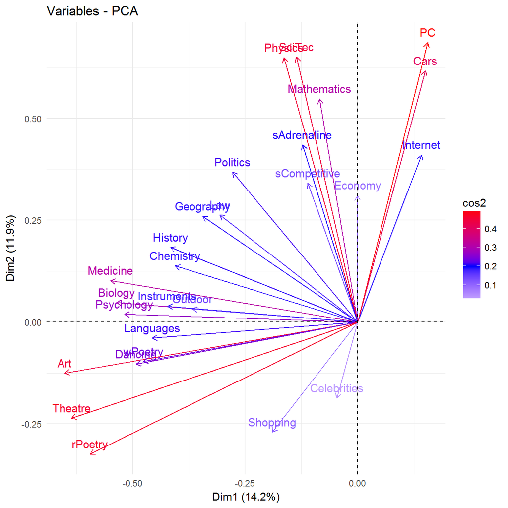

```r
# Biplot of loadings
library(factoextra)

biplot3 <- fviz_pca_var(pca1_hobby, col.var="cos2") + scale_color_gradient2(low="white", mid="blue", high="red", midpoint=0.2) + theme_minimal()

biplot3
```

## 6.2 Variable contribution to different dimensions

http://www.ic.unicamp.br/~wainer/cursos/1s2013/ml/Lecture18_PCA.pdf

http://geog.uoregon.edu/GeogR/topics/pca.html

http://www.sthda.com/english/wiki/principal-component-analysis-how-to-reveal-the-most-important-variables-in-your-data-r-software-and-data-mining#at_pco=smlwn-1.0&at_si=58bbc17c84dcd355&at_ab=per-2&at_pos=0&at_tot=1

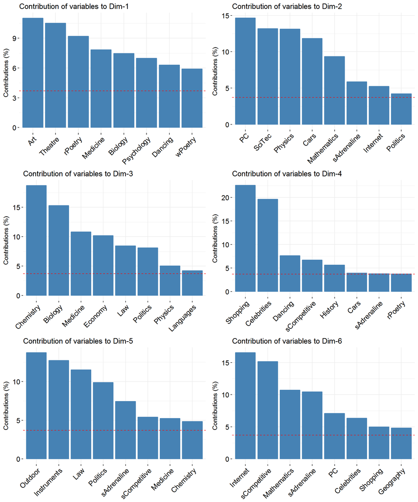

```r
library(factoextra); library(gridExtra)

# Contributions of variables on PC1
contr1 <- fviz_pca_contrib(pca1_hobby, choice = "var", axes = 1, top = 8)

# Contributions of variables on PC2
contr2 <- fviz_pca_contrib(pca1_hobby, choice = "var", axes = 2, top = 8)

# Contributions of variables on PC3
contr3 <- fviz_pca_contrib(pca1_hobby, choice = "var", axes = 3, top = 8)

# Contributions of variables on PC4
contr4 <- fviz_pca_contrib(pca1_hobby, choice = "var", axes = 4, top = 8)

# Contributions of variables on PC5
contr5 <- fviz_pca_contrib(pca1_hobby, choice = "var", axes = 5, top = 8)

# Contributions of variables on PC6
contr6 <- fviz_pca_contrib(pca1_hobby, choice = "var", axes = 6, top = 8)

# Printing all at once
grid.arrange(contr1, contr2, contr3, contr4, contr5, contr6, ncol = 2, nrow =3)
```

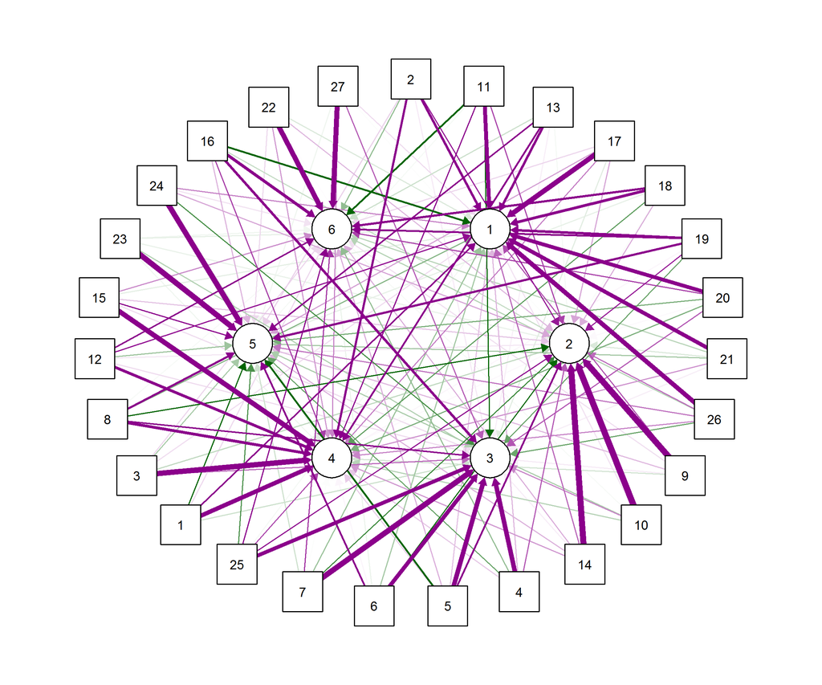

```r
library(qgraph)
qg_pca <- qgraph.pca(hobby, factors=6, rotation="varimax", posCol="darkmagenta", negCol="darkgreen")
```

```r
library(psych)
hobby_rot <- principal(r = std_hobby, nfactors = 6, rotate = "varimax", scores = T)
hobby_rot
```

```
## Principal Components Analysis
## Call: principal(r = std_hobby, nfactors = 6, rotate = "varimax", scores = T)
## Standardized loadings (pattern matrix) based upon correlation matrix
##                RC1   RC3   RC2   RC5   RC4   RC6   h2   u2 com
## History       0.25  0.01 -0.04  0.65 -0.23  0.03 0.54 0.46 1.6
## Psychology    0.39  0.19  0.02  0.35  0.04 -0.09 0.32 0.68 2.6
## Politics      0.03 -0.05  0.12  0.78 -0.07  0.03 0.63 0.37 1.1
## Mathematics   0.06  0.14  0.69  0.04 -0.12 -0.09 0.52 0.48 1.2
## Physics       0.05  0.32  0.67  0.04 -0.30  0.06 0.65 0.35 1.9
## Internet     -0.07 -0.20  0.59  0.01  0.31 -0.02 0.49 0.51 1.8
## PC           -0.08 -0.16  0.76  0.00 -0.04  0.17 0.64 0.36 1.2
## Economy      -0.10 -0.23  0.29  0.44  0.35 -0.01 0.46 0.54 3.4
## Biology       0.14  0.88  0.02 -0.04  0.06  0.03 0.80 0.20 1.1
## Chemistry     0.02  0.86  0.10 -0.06 -0.07 -0.01 0.76 0.24 1.0
## rPoetry       0.59  0.15 -0.20  0.22 -0.01 -0.30 0.56 0.44 2.3
## Geography     0.20  0.02  0.03  0.44 -0.08  0.28 0.32 0.68 2.2
## Languages     0.42 -0.01  0.01  0.31  0.27 -0.04 0.34 0.66 2.7
## Medicine      0.12  0.84  0.01  0.08  0.06  0.07 0.74 0.26 1.1
## Law          -0.02  0.05  0.03  0.72  0.24  0.09 0.59 0.41 1.3
## Cars         -0.29 -0.05  0.39  0.16  0.06  0.50 0.51 0.49 2.9
## Art           0.73  0.07 -0.02  0.11  0.08  0.03 0.55 0.45 1.1
## Outdoor       0.45  0.07  0.00 -0.13 -0.02  0.38 0.37 0.63 2.2
## Dancing       0.42  0.19 -0.12  0.01  0.37  0.30 0.46 0.54 3.5
## Instruments   0.59  0.00  0.14 -0.10 -0.11  0.15 0.41 0.59 1.4
## wPoetry       0.61 -0.03  0.01  0.09 -0.07 -0.06 0.39 0.61 1.1
## sCompetitive -0.03  0.06  0.00  0.08  0.03  0.73 0.55 0.45 1.0
## Celebrities  -0.02 -0.02 -0.06 -0.01  0.75 -0.01 0.57 0.43 1.0
## Shopping      0.10  0.07 -0.15 -0.02  0.78  0.02 0.65 0.35 1.1
## SciTec       -0.01  0.20  0.57  0.15 -0.15  0.24 0.47 0.53 2.0
## Theatre       0.68  0.12 -0.12  0.10  0.11 -0.06 0.52 0.48 1.2
## sAdrenaline   0.03  0.00  0.13  0.10 -0.01  0.72 0.54 0.46 1.1
##
##                        RC1  RC3  RC2  RC5  RC4  RC6
## SS loadings           3.03 2.64 2.57 2.35 1.91 1.86
## Proportion Var        0.11 0.10 0.10 0.09 0.07 0.07
## Cumulative Var        0.11 0.21 0.31 0.39 0.46 0.53
## Proportion Explained  0.21 0.18 0.18 0.16 0.13 0.13
## Cumulative Proportion 0.21 0.39 0.57 0.74 0.87 1.00
##
## Mean item complexity =  1.7
## Test of the hypothesis that 6 components are sufficient.
##
## The root mean square of the residuals (RMSR) is  0.06
##  with the empirical chi square  2179.93  with prob <  0
##
## Fit based upon off diagonal values = 0.88
```